# Congressional Statements Analysis

```python
import pickle
import requests
import numpy as np
from sklearn.linear_model import LinearRegression
import matplotlib.pyplot as plt
import pandas as pd
import seaborn as sns
from datetime import date
from bs4 import BeautifulSoup
import time
import math
# import json

image_path = "../ncrispino.github.io/images/pres-candidates-graphs/"

def propublica_data(url):
    return requests.get(url, headers={"X-API-Key": "api-key-here"}).json()

def paginated_request(url, num_results):
    """
    Given a url ending with 'offset=', creates a dataframe with the specified number of results (in multiples of 20)
    """
    dfs = []
    for i in range(0, num_results, 20):
        data = propublica_data(url + str(i))
        df = pd.DataFrame(data["results"][0])
        dfs.append(df)
    return pd.concat(dfs)


# Useful functions/definitions
def remove_spines(ax, sides=["top", "right"]):
    """
    Removes spines from all graphs in given axis. Works with an individual axis or list of axes.
    By default removes top and right spines. Returns ax.
    """
    for side in sides:
        try:
            for a in ax:
                a.spines[side].set_visible(False)
        except:
            ax.spines[side].set_visible(False)
    return ax
facecolor=(245/255, 245/255, 245/255)
```

### A Quick Look at Congressional Statements During Recessions

```python
# Get Recession Dates
recession_dates = pd.read_csv("cycle dates pasted.csv").apply(pd.to_datetime)
recession_dates
```

|  | peak | trough |
| --- | --- | --- |
| 0 | NaT | 1854-12-01 |
| 1 | 1857-06-01 | 1858-12-01 |
| 2 | 1860-10-01 | 1861-06-01 |
| 3 | 1865-04-01 | 1867-12-01 |
| 4 | 1869-06-01 | 1870-12-01 |
| 5 | 1873-10-01 | 1879-03-01 |
| 6 | 1882-03-01 | 1885-05-01 |
| 7 | 1887-03-01 | 1888-04-01 |
| 8 | 1890-07-01 | 1891-05-01 |
| 9 | 1893-01-01 | 1894-06-01 |
| 10 | 1895-12-01 | 1897-06-01 |
| 11 | 1899-06-01 | 1900-12-01 |
| 12 | 1902-09-01 | 1904-08-01 |
| 13 | 1907-05-01 | 1908-06-01 |
| 14 | 1910-01-01 | 1912-01-01 |
| 15 | 1913-01-01 | 1914-12-01 |
| 16 | 1918-08-01 | 1919-03-01 |
| 17 | 1920-01-01 | 1921-07-01 |
| 18 | 1923-05-01 | 1924-07-01 |
| 19 | 1926-10-01 | 1927-11-01 |
| 20 | 1929-08-01 | 1933-03-01 |
| 21 | 1937-05-01 | 1938-06-01 |
| 22 | 1945-02-01 | 1945-10-01 |
| 23 | 1948-11-01 | 1949-10-01 |
| 24 | 1953-07-01 | 1954-05-01 |
| 25 | 1957-08-01 | 1958-04-01 |
| 26 | 1960-04-01 | 1961-02-01 |
| 27 | 1969-12-01 | 1970-11-01 |
| 28 | 1973-11-01 | 1975-03-01 |
| 29 | 1980-01-01 | 1980-07-01 |
| 30 | 1981-07-01 | 1982-11-01 |
| 31 | 1990-07-01 | 1991-03-01 |
| 32 | 2001-03-01 | 2001-11-01 |
| 33 | 2007-12-01 | 2009-06-01 |
| 34 | 2020-02-01 | NaT |

```python
all_congress_dates = pd.read_csv("congress-dates-updated.csv")
all_congress_dates = all_congress_dates.set_index(["Congress", "Session"])[["Begin Date", "Adjourn Date"]].apply(pd.to_datetime)
all_congress_dates
```

| Congress | Session | Begin Date | Adjourn Date |
| --- | --- | --- | --- |
| 117 | 1 | 2021-01-03 | NaT |
| 116 | 2 | 2020-01-03 | 2021-01-03 |
|  | 1 | 2019-01-03 | 2020-01-03 |
| 115 | 2 | 2018-01-03 | 2019-01-03 |
|  | 1 | 2017-01-03 | 2018-01-03 |
| ... | ... | ... | ... |
| 2 | 1 | 1791-10-24 | 1792-05-08 |
|  | S | 1791-03-04 | 1791-03-04 |
| 1 | 3 | 1790-12-06 | 1791-03-03 |
|  | 2 | 1790-01-04 | 1790-08-12 |
|  | 1 | 1789-03-04 | 1789-09-29 |

305 rows × 2 columns

Get congressional sessions corresponding to times of recessions

```python
def date_range(df):
    """
    Returns series with pandas datetime range of [first_col, second_col] for each row
    """
    start = df.iloc[0]
    end = df.iloc[1]
    if pd.isna(start):
        start = end
    # means recession is ongoing
    if pd.isna(end):
        end = date.today()
    return pd.date_range(start, end)
recession_range = recession_dates.apply(date_range, axis=1)
congress_range = all_congress_dates.apply(date_range, axis=1)

# if there is a recession at any time--even a day--in the congressional session, the new df will be True at that session
def in_recession(df, min_days=1):
    """
    Given a df with a date range in each row,
    finds when those ranges interlap--by default, even by one day--with recessions.
    Returns dataframe with same indices as df and boolean values corresponding to the existence of an interlap.
    """
    for rr in recession_range.values:
        if df.isin(rr).sum() >= min_days:
            return True
    return False

congress_recessions = congress_range.transform(in_recession, min_days=1)
congress_recessions = congress_recessions.to_frame("Recession")
congress_recessions
```

| Congress | Session | Recession |
| --- | --- | --- |
| 117 | 1 | True |
| 116 | 2 | True |
|  | 1 | False |
| 115 | 2 | False |
|  | 1 | False |
| ... | ... | ... |
| 2 | 1 | False |
|  | S | False |
| 1 | 3 | False |
|  | 2 | False |
|  | 1 | False |

305 rows × 1 columns

### Statements Data

```python
def statements_paginated(statement_url, num_results, start=0, type_="statement"):
    """
    Takes a url corresponding to statements (w/o pagination) and returns a dataframe with the given number of results.
    Sometimes, the offset will not be valid, in which case the offset number will be printed and that offset will be skipped over.
    """
    data = []
    skipped_offset = []
    for i in range(start, num_results, 20):
        res = propublica_data(statement_url + f"&offset={i}")
        if res.get("results") == None:
            skipped_offset.append(i)
            continue
        res = res["results"]
        if len(res) == 0:
            break
        if type_ == "statement":
            df = pd.DataFrame(res)
            df["date"] = df["date"].apply(pd.to_datetime)
        elif type_ == "bill":
            df = pd.DataFrame(res[0]["bills"])
            df[["introduced_date", "latest_major_action_date"]] = df[["introduced_date", "latest_major_action_date"]].apply(pd.to_datetime)
        data.append(df)
    print(skipped_offset)
    if len(data) > 1:
        return pd.concat(data)
    elif len(data) == 1:
        return data[0]
    return pd.DataFrame()

def get_all_statements(url):
    """
    Given url without offset get all results for statment search based on query.
    Returns concatenated df.
    """
    num_results = propublica_data(url).get("num_results")
    if num_results == None:
        return pd.DataFrame()
    # can only get 5000 requests at once
    max_requests = 5000
    if num_results > max_requests:
        dfs = []
        for start in range(0, num_results, max_requests):
            df = statements_paginated(url, start + max_requests, start)
            dfs.append(df)
#             time.sleep(10)
        return pd.concat(dfs)
    else:
        df = statements_paginated(url, num_results)
        return df

def graph_differences(df):

    # add column that specifies if in recession
    def day_in_recession(x):
        """
        Returns true if day in recession, false otherwise.
        """
        for rr in recession_range.values:
            if x in rr:
                return True
        return False
    df["in_recession"] = df["date"].apply(day_in_recession)

    # graph total statments for all sessions
    session_recession = df.groupby(["congress", "in_recession"]).count()["url"]
    session_recession = session_recession.to_frame().rename(columns={"url": "count"})
    sns.catplot(x="congress", y="count", hue="in_recession", data=session_recession.reset_index(), kind="bar")

    #graph statements per day for all sessions
    session_recession
    # gets number of unique days with statements per session and recession status
    dates_per_sr = df[["congress", "in_recession", "date"]].groupby(["congress", "in_recession"]).nunique().rename(columns={"date": "count"})
    # gives statements per day mentioning unemployment for days in and out of recessions
    statements_per_day = session_recession/dates_per_sr
    statements_per_day
    sns.catplot(x="congress", y="count", hue="in_recession", data=statements_per_day.reset_index(), kind="bar")

    # now drop sessions that don't have both recessions and not recessions
    recession_and_not = statements_per_day.reset_index().groupby("congress")["in_recession"].agg(len) > 1
    statements_per_day.reset_index()["congress"].isin(recession_and_not)
    both_rec = statements_per_day.loc[recession_and_not[recession_and_not].index]
    sns.catplot(x="congress", y="count", hue="in_recession", data=both_rec.reset_index(), kind="bar")

    return statements_per_day
```

```python
url = "https://api.propublica.org/congress/v1/statements/search.json?query=treasury"
# df, statements_per_day = graph_differences(url)
# statements_paginated(url, 20)
# propublica_data(url + f"&offset=5220") #["results"]
# max_requests = 5000

# dfs = []
# df = statements_paginated(url, 12000, 10000)
# df["date"] = df["date"].apply(pd.to_datetime)
# dfs.append(df)

# treasury_df = get_all_statements(url)
# treasury_df

# save first df -- i think im out for today
# with open('treasury_df_1.pkl', 'wb') as f:
#     pickle.dump(dfs[0], f)
# with open('treasury_df_1.pkl', 'rb') as f:
#     treasury_df_1 = pickle.load(f)
# dfs.insert()
treasury_df = pd.concat(dfs).reset_index(drop=True)
treasury_df.head()
```

|  | url | date | title | statement_type | member_id | congress | member_uri | name | chamber | state | party | subjects |
| --- | --- | --- | --- | --- | --- | --- | --- | --- | --- | --- | --- | --- |
| 0 | https://www.moran.senate.gov/public/index.cfm/... | 2021-06-28 | Supporting Aviation Manufacturing in Wichita | Press Release | M000934 | 117 | https://api.propublica.org/congress/v1/members... | Jerry Moran | Senate | KS | R | [] |
| 1 | https://dankildee.house.gov/media/press-releas... | 2021-06-28 | Coronavirus Weekly Update: July 28 | Press Release | K000380 | 117 | https://api.propublica.org/congress/v1/members... | Dan Kildee | House | MI | D | [] |
| 2 | https://doggett.house.gov/media-center/in-the-... | 2021-06-28 | Dallas Morning News: Irate that Abbott could t... | Press Release | D000399 | 117 | https://api.propublica.org/congress/v1/members... | Lloyd Doggett | House | TX | D | [] |
| 3 | https://doggett.house.gov/media-center/press-r... | 2021-06-28 | No Federal Relief Funds to Build Abbott-Trump ... | Press Release | D000399 | 117 | https://api.propublica.org/congress/v1/members... | Lloyd Doggett | House | TX | D | [] |
| 4 | https://torres.house.gov/media-center/press-re... | 2021-06-25 | Torres Secures $1 Million for Cal Poly Pomona | Press Release | T000474 | 117 | https://api.propublica.org/congress/v1/members... | Norma Torres | House | CA | D | [] |

| congress | in_recession | count |
| --- | --- | --- |
| 105 | False | 1.055556 |
| 106 | False | 1.000000 |
| 107 | False | 1.136364 |
|  | True | 1.171429 |
| 108 | False | 1.197531 |
| 109 | False | 1.454545 |
| 110 | False | 1.310811 |
|  | True | 1.636364 |
| 111 | False | 1.943396 |
|  | True | 2.297297 |
| 112 | False | 1.468750 |
| 113 | False | 3.551220 |
| 114 | False | 3.409639 |
| 115 | False | 4.311340 |
| 116 | False | 5.069767 |
|  | True | 10.229730 |
| 117 | True | 4.648485 |

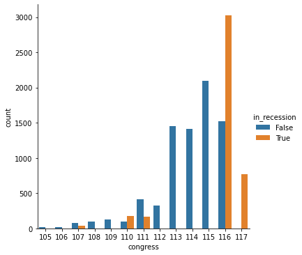

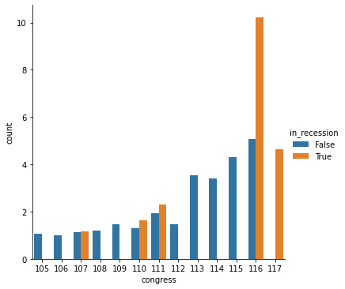

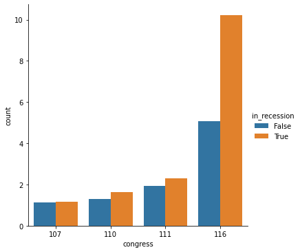

```python
treasury_statements_daily = graph_differences(treasury_df)
treasury_statements_daily
```

### More Statement Analysis: Do Presidential Candidates in Office Put out More Statements While Running?

Take the 2020 presidential candidates as contenders. Data taken from the [FEC](https://www.fec.gov/data/candidates/president/?election_year=2020&cycle=2020&election_full=true).

Also, can an increase in statements predict a presidential run (or run for higher office) in the future? Or maybe official statements decreases as candidates focus on campaigns

```python
pres_candidates = pd.read_csv("fec_presidential_candidates.csv")
pres_candidates.head()
```

|  | name | office | office_full | party | party_full | state | district | district_number | election_districts | election_years | ... | disbursements | cash_on_hand_end_period | debts_owed_by_committee | coverage_start_date | coverage_end_date | federal_funds_flag | has_raised_funds | party.1 | office.1 | candidate_inactive.1 |
| --- | --- | --- | --- | --- | --- | --- | --- | --- | --- | --- | --- | --- | --- | --- | --- | --- | --- | --- | --- | --- | --- |
| 0 | SENEY, RAYMOND J | P | President | DEM | DEMOCRATIC PARTY | US | 0 | 0 | {00} | {2020} | ... | 2.634690e+03 | 305.20 | 1800.00 | 2019-01-01 00:00:00 | 2020-12-31 00:00:00 | f | t | DEM | P | f |
| 1 | ANTHONY, NAKIA LACQUERS | P | President | DEM | DEMOCRATIC PARTY | US | 0 | 0 | {00} | {2020} | ... | 6.363000e+03 | 0.00 | 0.00 | 2019-07-01 00:00:00 | 2020-10-01 00:00:00 | f | t | DEM | P | f |
| 2 | LEFFERT, AKIVA | P | President | DEM | DEMOCRATIC PARTY | US | 0 | 0 | {00} | {2020} | ... | 9.474000e+01 | 979.09 | 0.00 | 2019-01-01 00:00:00 | 2020-03-31 00:00:00 | f | t | DEM | P | f |
| 3 | WARREN, ELIZABETH | P | President | DEM | DEMOCRATIC PARTY | US | 0 | 0 | {00} | {2020} | ... | 1.311896e+08 | 178499.13 | 439337.03 | 2019-01-01 00:00:00 | 2020-12-31 00:00:00 | f | t | DEM | P | f |
| 4 | LEWIS, BILLY R MR III | P | President | AIP | AMERICAN INDEPENDENT PARTY | US | 0 | 0 | {00} | {2020} | ... | 0.000000e+00 | 0.00 | 0.00 | NaN | NaN | f | f | AIP | P | f |

5 rows × 43 columns

Now, get members of Congress from ProPublica

```python
# look at congressional sessions 115 and 116 -- from 2017 to 2021
def get_congress_members(congress_sessions):
    congress_members_dfs = []
    for con in congress_sessions:
        for ch in ["house", "senate"]:
            url = f"https://api.propublica.org/congress/v1/{con}/{ch}/members.json"
            df = pd.DataFrame(propublica_data(url)["results"][0]["members"])
            # add column with congressional session
            df["congress"] = con
            congress_members_dfs.append(df)
    congress_members = pd.concat(congress_members_dfs)
    # add new column to congress_members with name of form (last_name, first_name)
    congress_members["full_name"] = congress_members["last_name"] + ", " + congress_members["first_name"]
    return congress_members
congress_members = get_congress_members([115, 116])
congress_members
```

|  | id | title | short_title | api_uri | first_name | middle_name | last_name | suffix | date_of_birth | gender | ... | at_large | geoid | missed_votes_pct | votes_with_party_pct | votes_against_party_pct | congress | senate_class | state_rank | lis_id | full_name |
| --- | --- | --- | --- | --- | --- | --- | --- | --- | --- | --- | --- | --- | --- | --- | --- | --- | --- | --- | --- | --- | --- |
| 0 | A000374 | Representative | Rep. | https://api.propublica.org/congress/v1/members... | Ralph | None | Abraham | None | 1954-09-16 | M | ... | False | 2205 | 1.49 | 97.56 | 2.44 | 115 | NaN | NaN | NaN | Abraham, Ralph |
| 1 | A000370 | Representative | Rep. | https://api.propublica.org/congress/v1/members... | Alma | None | Adams | None | 1946-05-27 | F | ... | False | 3712 | 2.64 | 98.52 | 1.48 | 115 | NaN | NaN | NaN | Adams, Alma |
| 2 | A000055 | Representative | Rep. | https://api.propublica.org/congress/v1/members... | Robert | B. | Aderholt | None | 1965-07-22 | M | ... | False | 0104 | 4.13 | 97.58 | 2.42 | 115 | NaN | NaN | NaN | Aderholt, Robert |
| 3 | A000371 | Representative | Rep. | https://api.propublica.org/congress/v1/members... | Pete | None | Aguilar | None | 1979-06-19 | M | ... | False | 0631 | 1.16 | 95.19 | 4.81 | 115 | NaN | NaN | NaN | Aguilar, Pete |
| 4 | A000372 | Representative | Rep. | https://api.propublica.org/congress/v1/members... | Rick | None | Allen | None | 1951-11-07 | M | ... | False | 1312 | 1.32 | 98.57 | 1.43 | 115 | NaN | NaN | NaN | Allen, Rick |
| ... | ... | ... | ... | ... | ... | ... | ... | ... | ... | ... | ... | ... | ... | ... | ... | ... | ... | ... | ... | ... | ... |
| 97 | W000817 | Senator, 1st Class | Sen. | https://api.propublica.org/congress/v1/members... | Elizabeth | None | Warren | None | 1949-06-22 | F | ... | NaN | NaN | 39.47 | 78.67 | 21.33 | 116 | 1 | senior | S366 | Warren, Elizabeth |
| 98 | W000802 | Senator, 1st Class | Sen. | https://api.propublica.org/congress/v1/members... | Sheldon | None | Whitehouse | None | 1955-10-20 | M | ... | NaN | NaN | 8.09 | 93.63 | 6.37 | 116 | 1 | junior | S316 | Whitehouse, Sheldon |
| 99 | W000437 | Senator, 1st Class | Sen. | https://api.propublica.org/congress/v1/members... | Roger | None | Wicker | None | 1951-07-05 | M | ... | NaN | NaN | 0.14 | 98.73 | 1.27 | 116 | 1 | senior | S318 | Wicker, Roger |
| 100 | W000779 | Senator, 3rd Class | Sen. | https://api.propublica.org/congress/v1/members... | Ron | None | Wyden | None | 1949-05-03 | M | ... | NaN | NaN | 1.53 | 85.36 | 14.64 | 116 | 3 | senior | S247 | Wyden, Ron |
| 101 | Y000064 | Senator, 3rd Class | Sen. | https://api.propublica.org/congress/v1/members... | Todd | None | Young | None | 1972-08-24 | M | ... | NaN | NaN | 1.81 | 94.99 | 5.01 | 116 | 3 | senior | S391 | Young, Todd |

1114 rows × 51 columns

```python
congress_members.info()
congress_members["next_election"]
```

```
<class 'pandas.core.frame.DataFrame'>
Int64Index: 1114 entries, 0 to 101
Data columns (total 49 columns):
 #   Column                   Non-Null Count  Dtype
---  ------                   --------------  -----
 0   id                       1114 non-null   object
 1   title                    1114 non-null   object
 2   short_title              1114 non-null   object
 3   api_uri                  1114 non-null   object
 4   first_name               1114 non-null   object
 5   middle_name              178 non-null    object
 6   last_name                1114 non-null   object
 7   suffix                   14 non-null     object
 8   date_of_birth            1114 non-null   object
 9   gender                   1114 non-null   object
```

[output cut: 41 more lines]

```
0      2018
1      2018
2      2018
3      2018
4      2018
       ...
97     2024
98     2024
99     2024
100    2022
101    2022
Name: next_election, Length: 1114, dtype: object
```

The names in pres_candidates are all capitalized and combined; so, need to remove middle names (due to varying format w/ and w/o ".") and change to same capitalization as the names in congress_members.

```python
# remove middle names from pres_candidates df
import re
pres_names = []
for pcn in pres_candidates["name"].values:
    pres_names.append(re.sub(r"\s[A-Z]{1,2}\.$|\s[A-Z]$", "", pcn).title())
# get full (no middle) names
congress_names = congress_members["last_name"] + ", " + congress_members["first_name"]
# # add congress_names as column to congress_members
congress_members["full_name"] = congress_names

# find intersection
pres_cong_names = set(pres_names).intersection(set(congress_names))
pres_cong_names
```

```
{'Amash, Justin',
 'Bennet, Michael',
 'Booker, Cory',
 'Delaney, John',
 'Gabbard, Tulsi',
 'Gillibrand, Kirsten',
 'Harris, Kamala',
 'Klobuchar, Amy',
 'Moulton, Seth',
 'Sanders, Bernard',
 'Warren, Elizabeth'}
```

The above way is cool, but because there are only 12 names, I can manually place them without needing to worry about middle names, abbreviations, party affiliation, etc.

```python
campaign_dates = dict()
campaign_dates["Gabbard, Tulsi"] = ["Jan 11, 2019", "March 19, 2020"]
campaign_dates["Harris, Kamala"] = ["Jan 11, 2019", "Dec 3, 2019"]
campaign_dates["Booker, Cory"] = ["Feb 1, 2019", "Jan 13, 2020"]
campaign_dates["Warren, Elizabeth"] = ["Feb 9, 2019", "March 5, 2020"]
campaign_dates["Klobuchar, Amy"] = ["Feb 10, 2019", "March 2, 2020"]
campaign_dates["Sanders, Bernard"] = ["Feb 19, 2019", "April 8, 2020"]
campaign_dates["Gillibrand, Kirsten"] = ["March 17, 2019", "August 28, 2019"]
campaign_dates["Ryan, Tim"] = ["April 4, 2019", "Oct 24, 2019"]
campaign_dates["Swalwell, Eric"] = ["April 8, 2019", "July 8, 2019"]
campaign_dates["Bennet, Michael"] = ["May 2, 2019", "Feb 11, 2020"]
campaign_dates["Moulton, Seth"] = ["April 22, 2019", "Aug 23, 2019"]
campaign_dates["Delaney, John"] = ["July 28, 2017", "Jan 31, 2020"]
```

First, get member ids for each democratic presidential candidate in Congress

```python
member_ids = congress_members.drop_duplicates(subset="full_name", keep="first").set_index("full_name").loc[campaign_dates.keys(), "id"]
member_ids
```

```
full_name
Gabbard, Tulsi         G000571
Harris, Kamala         H001075
Booker, Cory           B001288
Warren, Elizabeth      W000817
Klobuchar, Amy         K000367
Sanders, Bernard       S000033
Gillibrand, Kirsten    G000555
Ryan, Tim              R000577
Swalwell, Eric         S001193
Bennet, Michael        B001267
Moulton, Seth          M001196
Delaney, John          D000620
Name: id, dtype: object
```

```python
def statements_by_name(full_name, sessions):
    """
    Given full name finds member id from congress_members df, then finds all statements in the given congressional sessions.
    Returns df with all statements.
    """
    # only get one row with Congressmember's full_name because many congressmembers serve multiple terms and thus will have multiple rows in df
    member_id = congress_members.drop_duplicates(subset="full_name", keep="first").set_index("full_name").loc[full_name, "id"]
#     print(member_id)
    dfs = []
    for s in sessions:
        url = f"https://api.propublica.org/congress/v1/members/{member_id}/statements/{s}.json?"
        df = get_all_statements(url)
        # adds name and congressional session to each row for ease of grouping
        if ~df.empty:
            df["name"] = full_name
            df["session"] = s
            dfs.append(df)
    return pd.concat(dfs)
# sessions = [115, 116]
# dfs = []
# for name in list(member_ids.index):
#     dfs.append(statements_by_name(name, sessions))
# pres_statements_df = pd.concat(dfs).reset_index(drop=True)
# pres_statements_df

# pickling to save
# with open('pres_statements_df.pkl', 'wb') as f:
#     pickle.dump(pres_statements_df, f)
with open('pres_statements_df.pkl', 'rb') as f:
    pres_statements_df = pickle.load(f)
pres_statements_df
```

|  | url | date | title | statement_type | chamber | state | party | subjects | name | session |
| --- | --- | --- | --- | --- | --- | --- | --- | --- | --- | --- |
| 0 | https://gabbard.house.gov/news/press-releases/... | 2017-02-08 | Rep. Tulsi Gabbard: Working Families Deserve P... | Press Release | House | HI | D | [] | Gabbard, Tulsi | 115 |
| 1 | https://gabbard.house.gov/news/press-releases/... | 2017-02-07 | Rep. Tulsi Gabbard Statement on Amnesty Intern... | Press Release | House | HI | D | [] | Gabbard, Tulsi | 115 |
| 2 | https://gabbard.house.gov/news/press-releases/... | 2017-02-06 | Gabbard Backed Bill to Strengthen Online Priva... | Press Release | House | HI | D | [] | Gabbard, Tulsi | 115 |
| 3 | https://gabbard.house.gov/news/press-releases/... | 2017-02-03 | Rep. Tulsi Gabbard Cosponsors Bill to Expedite... | Press Release | House | HI | D | [] | Gabbard, Tulsi | 115 |
| 4 | https://gabbard.house.gov/news/press-releases/... | 2017-02-01 | Rep. Tulsi Gabbard, Lawmakers Call For Reinsta... | Press Release | House | HI | D | [] | Gabbard, Tulsi | 115 |
| ... | ... | ... | ... | ... | ... | ... | ... | ... | ... | ... |
| 11344 | http://delaney.house.gov/news/press-releases/d... | 2017-01-11 | Delaney Applauds Federal Grant for Road Improv... | Press Release | House | MD | D | [] | Delaney, John | 115 |
| 11345 | http://delaney.house.gov/news/press-releases/d... | 2017-01-09 | Delaney, Yoho, Davis to Introduce Bipartisan B... | Press Release | House | MD | D | [] | Delaney, John | 115 |
| 11346 | http://delaney.house.gov/news/blogs/on-the-hou... | 2017-01-09 | On the House Floor This Week - 1/9/2017 | Press Release | House | MD | D | [] | Delaney, John | 115 |
| 11347 | http://delaney.house.gov/news/press-releases/h... | 2017-01-05 | House Passes Measure Objecting to U.N. Resolut... | Press Release | House | MD | D | [] | Delaney, John | 115 |
| 11348 | http://delaney.house.gov/news/press-releases/d... | 2017-01-03 | Delaney Statement on Opening of 115th Congress | Press Release | House | MD | D | [] | Delaney, John | 115 |

11349 rows × 10 columns

Now, graph statements over time for each presidential candidate in Congress.

I'll consider 2020 presidential campaigns to begin in January 2019, due to many contenders announcing [then](https://en.wikipedia.org/wiki/2020_Democratic_Party_presidential_primaries#January_2019) or later; also, I'll consider the end (due to most candidates dropping out) on Feb 3, the day of the Iowa Caucuses.

```python
campaign_dates_all = ["Jan 1, 2019", "Feb 3, 2020"]
cand_names = member_ids.index
# Get statements by name and day, then by name and month
pres_statements_day = pres_statements_df.groupby(["name", "date"]).count()["url"]
pres_statements_month = pres_statements_day.groupby(["name", pd.Grouper(freq="4W", level="date")]).sum()
```

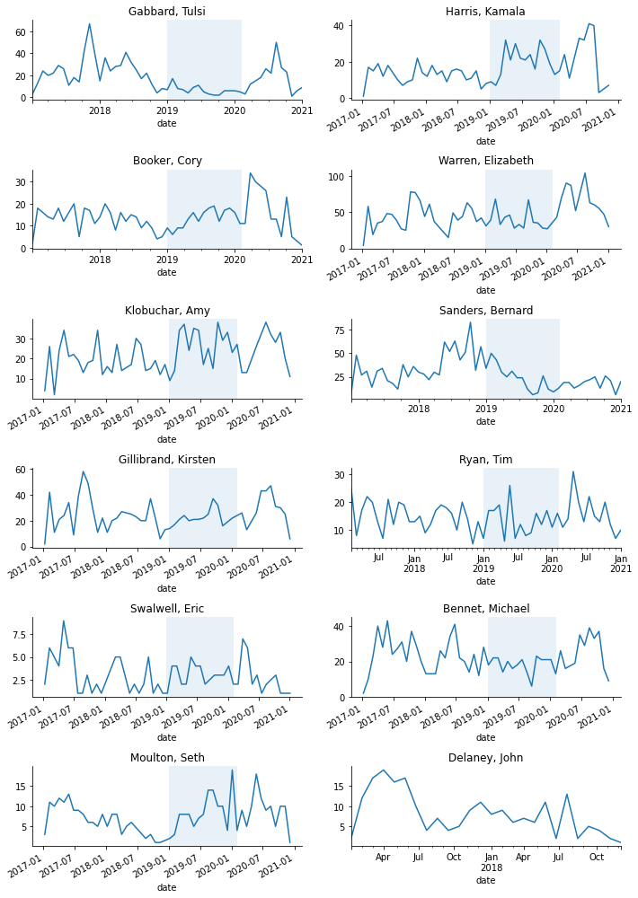

```python
# fig, ax = plt.subplots(math.floor(len(pres_cong_names)**0.5), math.ceil(len(pres_cong_names)**0.5), figsize=(10, 8))
fig, ax = plt.subplots(6, 2, figsize=(10, 14))

# plot on each axis and highlight presidential primary dates
for name, a in zip(cand_names, ax.flatten()):
    pres_statements_month.loc[name, :, :].reset_index("name", drop=True).plot(ax=a, title=name)
    a.axvspan(campaign_dates_all[0], campaign_dates_all[1], alpha=0.1)
#     a.set_facecolor(facecolor)
remove_spines(ax.flatten())
# fig.set_facecolor(facecolor)
fig.tight_layout()
# fig.delaxes(ax.flatten()[-1])
# fig.savefig("graphs/statements_same_season.png", dpi=200)
```

There doesn't seem to be evidence of any large changes in statements.

Instead, I'll analyze each candidate individually, placing a span over the date where their campaign started (officially, not announcing an exploratory committee) and where their campaign ended (or campaign was suspended).

yo what happened to eric swalwell and tim ryan

```python
pres_statements_month
```

```
name               date
Bennet, Michael    2017-01-08     2
                   2017-02-05    10
                   2017-03-05    23
                   2017-04-02    40
                   2017-04-30    28
                                 ..
Warren, Elizabeth  2020-09-13    63
                   2020-10-11    60
                   2020-11-08    55
                   2020-12-06    47
                   2021-01-03    30
Name: url, Length: 586, dtype: int64
```

Write a function to graph congressional action (like statements and bills) given a df with said data and the names and campaign start/end dates of candidates.

```python
def graph_congress_actions(df, campaign_dates):
    """
    Takes a df with congressional actions taken by Congress members with an index of (name, date)
    (with the Congress members as the keys of campaign_dates) and graphs it over time with shading based on campaign_dates.
    Returns the resulting figure.
    """
    fig, ax = plt.subplots(6, 2, figsize=(10, 14))
    for name, a in zip(campaign_dates.keys(), ax.flatten()):
        curr_df = df.loc[name, :, :].reset_index("name", drop=True)
        curr_df.plot(ax=a, xlabel="", ylabel="", color="royalblue", zorder=2)
        cds = campaign_dates[name]
        a.set_title(name, fontname="Palatino Linotype")
        a.grid(zorder=0, alpha=0.5)
        a.tick_params(axis="y", color="gray", length=7)
        a.tick_params(axis="x", which="both", color="gray", length=4)
        a.axvspan(cds[0], cds[1], alpha=0.1, color="black")
#         a.set_facecolor(facecolor)
        remove_spines(a, sides=["top", "right", "bottom", "left"])
    fig.tight_layout()
    return fig
```

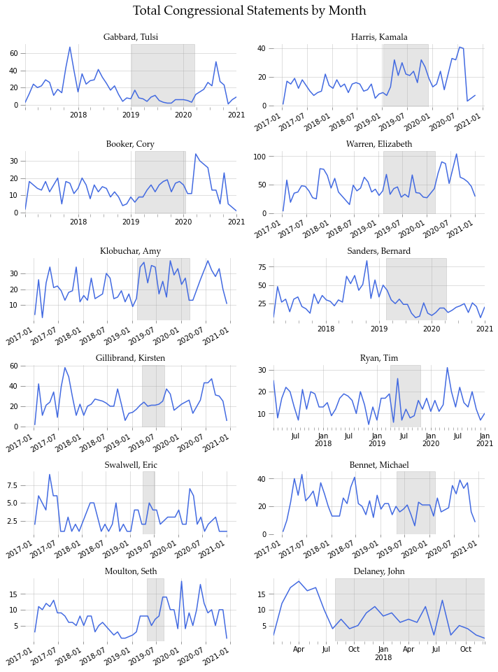

```python
fig = graph_congress_actions(pres_statements_month, campaign_dates)
fig.suptitle("Total Congressional Statements by Month", fontname="Palatino Linotype", fontsize=18)
rect = [0, 0.03, 1, 0.98]
fig.tight_layout(rect=rect)
# fig.savefig(image_path + "statements_total_by_cand.png", dpi=200)
```

Use above graph instead (used function to standardize plotting).

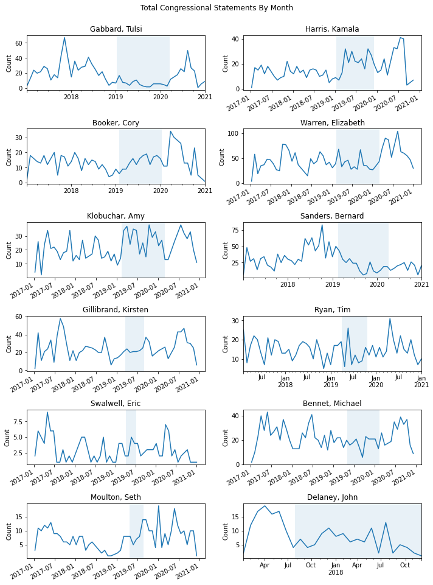

```python
# fig, ax = plt.subplots(math.floor(len(pres_cong_names)**0.5), math.ceil(len(pres_cong_names)**0.5), figsize=(10, 8))
fig, ax = plt.subplots(6, 2, figsize=(10, 14))
# plot on each axis and highlight presidential primary dates
for name, a in zip(cand_names, ax.flatten()):
    pres_statements_month.loc[name, :, :].reset_index("name", drop=True).plot(ax=a, title=name, xlabel="", ylabel="Count")
    cds = campaign_dates[name]
    a.axvspan(cds[0], cds[1], alpha=0.1)
fig.suptitle("Total Congressional Statements By Month")
# remove_spines(ax.flatten(), sides=["bottom", "left", "right"])
fig.tight_layout(rect=rect)
# fig.delaxes(ax.flatten()[-1])
# fig.savefig("graphs/statements_seasons_by_cand.png", dpi=200)
# fig.savefig(image_path + "statements_seasons_by_cand.png", dpi=200)
```

Remember, looking at sum of all statements by month. So, total statements could increase or decrease.

```python
pres_statements_month
```

```
name               date
Bennet, Michael    2017-01-08     2
                   2017-02-05    10
                   2017-03-05    23
                   2017-04-02    40
                   2017-04-30    28
                                 ..
Warren, Elizabeth  2020-09-13    63
                   2020-10-11    60
                   2020-11-08    55
                   2020-12-06    47
                   2021-01-03    30
Name: url, Length: 586, dtype: int64
```

### Bills and Votes

See if presidential campaigns correspond with more bills written/sponsored?

Also see if presidential campaigns correspond with more absences regarding votes taken?

#### Bills

Get bills introduced

```python
# save pres_cand_bills
# with open('pres_cand_bills.pkl', 'wb') as f:
#     pickle.dump(pres_cand_bills, f)
with open('pres_cand_bills.pkl', 'rb') as f:
    pres_cand_bills = pickle.load(f)
```

```python
def bills_by_member(member_id, bill_type):
    """
    Gets all bills given member id and bill_type (introduced, updated, active, passed, enacted or vetoed)
    """
    url = f"https://api.propublica.org/congress/v1/members/{member_id}/bills/{bill_type}.json?" # DON'T FORGET '?' in urls!!
    num_results = propublica_data(url)["results"][0]["num_results"]
    return statements_paginated(url, num_results, type_="bill")

def bills_all_members(member_ids, bill_type):
    """
    Gets all bills for a list of congressmembers given their member ids.
    """
    dfs = []
    for m_id in member_ids:
        df = bills_by_member(m_id, bill_type)
        dfs.append(df)
    return pd.concat(dfs)

# bill_type = "introduced"
# pres_cand_bills = bills_all_members(member_ids, bill_type).reset_index(drop=True)
# # put name in (lastname, firstname) order to standardize with statement dfs
# pres_cand_bills = pres_cand_bills.merge(member_ids.to_frame().reset_index(), left_on="sponsor_id", right_on="id")
# pres_cand_bills.rename(columns={"full_name": "name"}, inplace=True)
pres_cand_bills.head()
```

|  | congress | bill_id | bill_type | number | bill_uri | title | short_title | sponsor_title | sponsor_id | sponsor_name | ... | cosponsors | cosponsors_by_party | committees | primary_subject | summary | summary_short | latest_major_action_date | latest_major_action | name | id |
| --- | --- | --- | --- | --- | --- | --- | --- | --- | --- | --- | --- | --- | --- | --- | --- | --- | --- | --- | --- | --- | --- |
| 0 | 116 | hr9037-116 | hr | H.R.9037 | https://api.propublica.org/congress/v1/116/bil... | To amend the Public Health Service Act to ensu... | To amend the Public Health Service Act to ensu... | Rep. | G000571 | Tulsi Gabbard | ... | 0 | {} | House Energy and Commerce Committee |  |  |  | 2020-12-20 | Referred to the House Committee on Energy and ... | Gabbard, Tulsi | G000571 |
| 1 | 116 | hres1270-116 | hres | H.RES.1270 | https://api.propublica.org/congress/v1/116/bil... | Expressing the sense of the House of Represent... | Expressing the sense of the House of Represent... | Rep. | G000571 | Tulsi Gabbard | ... | 0 | {} | House Foreign Affairs Committee | International Affairs | This resolution expresses the sense of the Hou... | This resolution expresses the sense of the Hou... | 2020-12-18 | Referred to the House Committee on Foreign Aff... | Gabbard, Tulsi | G000571 |
| 2 | 116 | hres1267-116 | hres | H.RES.1267 | https://api.propublica.org/congress/v1/116/bil... | Expressing the sense of the House of Represent... | Expressing the sense of the House of Represent... | Rep. | G000571 | Tulsi Gabbard | ... | 0 | {} | House Small Business Committee | Taxation |  |  | 2020-12-17 | Referred to the Committee on Ways and Means, a... | Gabbard, Tulsi | G000571 |
| 3 | 116 | hr8968-116 | hr | H.R.8968 | https://api.propublica.org/congress/v1/116/bil... | To authorize the Secretary of the Army, acting... | Remote, Coastal, and Small Watersheds Act of 2020 | Rep. | G000571 | Tulsi Gabbard | ... | 1 | {'R': 1} | House Transportation and Infrastructure Committee |  |  |  | 2020-12-16 | Referred to the Subcommittee on Water Resource... | Gabbard, Tulsi | G000571 |
| 4 | 116 | hr8970-116 | hr | H.R.8970 | https://api.propublica.org/congress/v1/116/bil... | To repeal the USA PATRIOT Act and the FISA Ame... | To repeal the USA PATRIOT Act and the FISA Ame... | Rep. | G000571 | Tulsi Gabbard | ... | 1 | {'R': 1} | House Armed Services Committee |  |  |  | 2020-12-15 | Referred to the Committee on the Judiciary, an... | Gabbard, Tulsi | G000571 |

5 rows × 33 columns

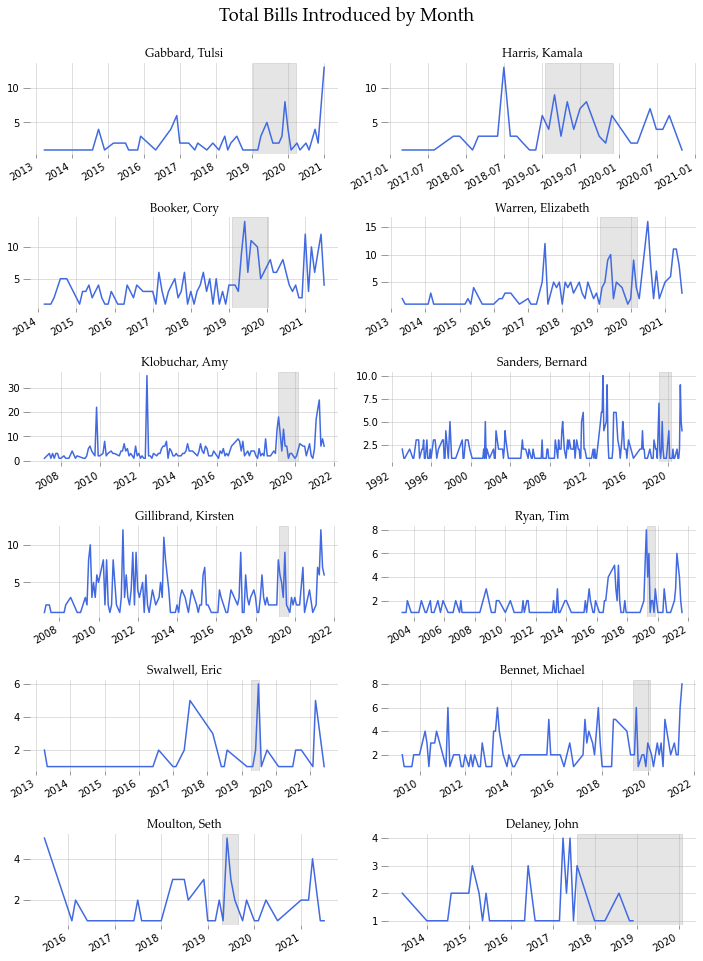

```python
# Get bills per month
introduced_bills = pres_cand_bills.groupby(["name", pd.Grouper(key="introduced_date", freq="M")])["bill_id"].count()
fig = graph_congress_actions(introduced_bills, campaign_dates)
fig.suptitle("Total Bills Introduced by Month", fontname="Palatino Linotype", fontsize=18)
fig.tight_layout(rect=rect)
# ax = fig.get_axes()
# fig.delaxes(ax[-1])
# introduced_bills
# fig.savefig(image_path + "bills_introduced.png", dpi=200)
```

Is this true for other congressmembers? Is this a common time for the introduction of bills?

#### Votes

Get member vote statistics (missed_votes_pct, votes_with_party_pct, votes_against_party_pct) for each Congress. (remove John Delaney as he isn't in Congress 116, the main Congress we're focused on)

```python
congress_members_more = get_congress_members([i for i in range(113, 118)])
member_names = member_ids.drop("Delaney, John").index
pres_cong_members = congress_members_more[congress_members_more["full_name"].isin(member_names)].set_index("full_name")
not_pres_cong_members = congress_members_more[~congress_members_more["full_name"].isin(member_names)].set_index("full_name")

# add if I want another column specifying the current row defines congress 116
# pres_cong_members["is_116"] = pres_cong_members["congress"] == 116
```

```python
def graph_vote_stats(vote_df, stat_name, member_names):
    fig, ax = plt.subplots(6, 2, figsize=(10, 14)) #, sharey=True)
    for name, a in zip(member_names, ax.flatten()):
        df = vote_df.loc[name, ["congress", stat_name]].reset_index("full_name", drop=True).set_index("congress")
        colors = ["royalblue" if x == 116 else "gainsboro" for x in df.index]
        # need to make df into series to cycle colors in plot
        (df[stat_name].plot(ax=a, kind="bar", title=name, legend=False, zorder=2,
              xlabel="", ylabel="", color=colors)
        )
        a.set_title(name, fontname="Palatino Linotype")
        a.grid(axis="y", zorder=0, alpha=0.5)
        a.tick_params(axis="y", color="gray", length=7)
        a.tick_params(axis="x", which="both", color="gray", length=4, labelrotation=0)
        remove_spines(a, sides=["top", "right", "bottom", "left"])
    fig.delaxes(ax.flatten()[-1])
    return fig
```

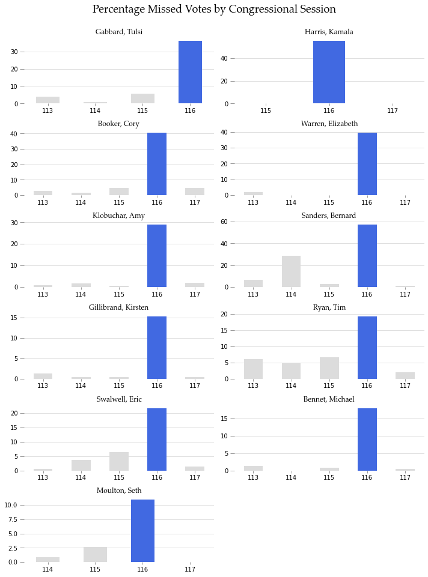

```python
fig = graph_vote_stats(pres_cong_members, "missed_votes_pct", member_names)
fig.suptitle("Percentage Missed Votes by Congressional Session", fontname="Palatino Linotype", fontsize=18)
fig.tight_layout(rect=rect)
# fig.savefig(image_path + "missed_votes.png", dpi=200)
```

Use above graph (created with function).

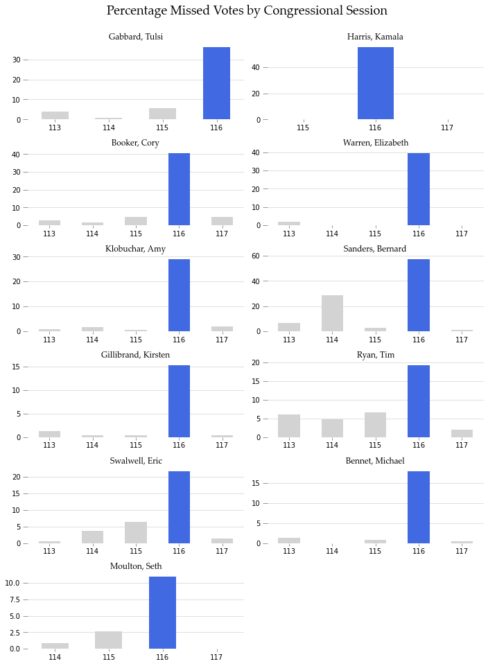

```python
fig, ax = plt.subplots(6, 2, figsize=(10, 14)) #, sharey=True)
for name, a in zip(member_names, ax.flatten()):
    df = pres_cong_members.loc[name, ["congress", "missed_votes_pct"]].reset_index("full_name", drop=True).set_index("congress")
    colors = ["royalblue" if x == 116 else "lightgray" for x in df.index]
    # need to make df into series to cycle colors in plot
    (df["missed_votes_pct"].plot(ax=a, kind="bar", title=name, legend=False, zorder=2,
          xlabel="", ylabel="", color=colors)
    )
    a.set_title(name, fontname="Palatino Linotype")
    a.grid(axis="y", zorder=0, alpha=0.5)
    a.tick_params(axis="y", color="gray", length=7)
    a.tick_params(axis="x", which="both", color="gray", length=4, labelrotation=0)
#     a.axvspan(cds[0], cds[1], alpha=0.1, color="black")
    remove_spines(a, sides=["top", "right", "bottom", "left"])

fig.suptitle("Percentage Missed Votes by Congressional Session", fontname="Palatino Linotype", fontsize=18)
fig.tight_layout(rect=rect)
# # ax.flatten()[0].patches[-1]
fig.delaxes(ax.flatten()[-1])
# fig.savefig(image_path + "missed_votes.png", dpi=200)
```

Wow! Everyone missed session 116, which was the main campaign period.

However... covid-19

```python
congress_members_more.groupby("congress")["missed_votes_pct"].mean()
```

```
congress
113    4.203532
114    3.823630
115    4.975351
116    4.672355
117    2.295603
Name: missed_votes_pct, dtype: float64
```

As seen above, the graphs may seem conclusive... perhaps they are, as the mean missed vote pct is ~4.7%

As a related question, who are the n members of Congress with the largest?

```python
congress_members_more.query("congress == 116").nlargest(10, columns="missed_votes_pct")[["full_name", "missed_votes_pct"]]
```

|  | full_name | missed_votes_pct |
| --- | --- | --- |
| 313 | Pelosi, Nancy | 90.99 |
| 328 | Radewagen, Amata | 77.53 |
| 78 | Sanders, Bernard | 57.32 |
| 37 | Harris, Kamala | 55.23 |
| 354 | San Nicolas, Michael | 50.63 |
| 282 | Mitchell, Paul | 50.00 |
| 259 | Marino, Tom | 44.44 |
| 7 | Booker, Cory | 40.45 |
| 0 | Abraham, Ralph | 39.52 |
| 97 | Warren, Elizabeth | 39.47 |

Interesting! Pelosi's votes don't count due to her status as speaker, and Radewagen, Amata and San Nicolas, Michael are representatives from US territories, not states. That leaves 4 out of the 10 congressmembers with the highest missed vote percentage as those running for president.

Returning to the analysis, the find the mean percentage of missed votes for the group of presidential candidates and regular congressmembers.

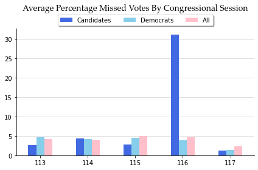

```python
# congress_members_more.loc[member_ids].groupby("congress")["missed_votes_pct"].mean()
missed_votes_total = (congress_members_more
                           .groupby("congress")["missed_votes_pct"].mean()
                           .rename("All"))
missed_votes_candidates = (congress_members_more[congress_members_more["full_name"].isin(member_ids.index)]
                           .groupby("congress")["missed_votes_pct"].mean()
                           .rename("Candidates"))
missed_votes_noncandidates = (congress_members_more[~congress_members_more["full_name"].isin(member_ids.index)]
                              .groupby("congress")["missed_votes_pct"].mean()
                              .rename("Non-candidates"))
missed_votes_dems = (congress_members_more
                              .groupby(["congress", "party"])["missed_votes_pct"].mean().loc[:, "D", :]
                              .rename("Democrats"))
# display(missed_votes_candidates)
# display(missed_votes_noncandidates)
fig, ax = plt.subplots()
missed_votes_all = missed_votes_candidates.to_frame().join(missed_votes_dems.to_frame()).join(missed_votes_total.to_frame())
missed_votes_all.plot(ax=ax, kind="bar", color=["royalblue", "skyblue", "pink"], xlabel="", ylabel="", zorder=2, rot=0)
ax.grid(axis="y", zorder=0, alpha=0.5)
# make legend look nice
handles, labels = ax.get_legend_handles_labels()
# fig.subplots_adjust(bottom=0, top=0.05)
ax.legend(handles, labels, ncol=3, loc="center", bbox_to_anchor=(0.5, 1.07), fancybox=True, shadow=True)
ax.set_title("Average Percentage Missed Votes By Congressional Session", pad=30, fontname="Palatino Linotype", fontsize=14)

remove_spines(ax)
fig.tight_layout()
# fig.savefig(image_path + "missed_votes_summary.png", dpi=200)
```

```python
# congress_members_more.groupby(["congress", "party"])["missed_votes_pct"].mean()
# congress_members_more[congress_members_more["full_name"] == "Sanders, Bernard"]["party"]
```

[output not shown]

Wow! Candidates really do miss a lot more of the vote... and so many barely got support. This begs the question: does running for president boost your impact? Check out this section of the notebook for more.

Another question: do presidential candidates vote more with their party (or against others) during their presidential primary sessions?

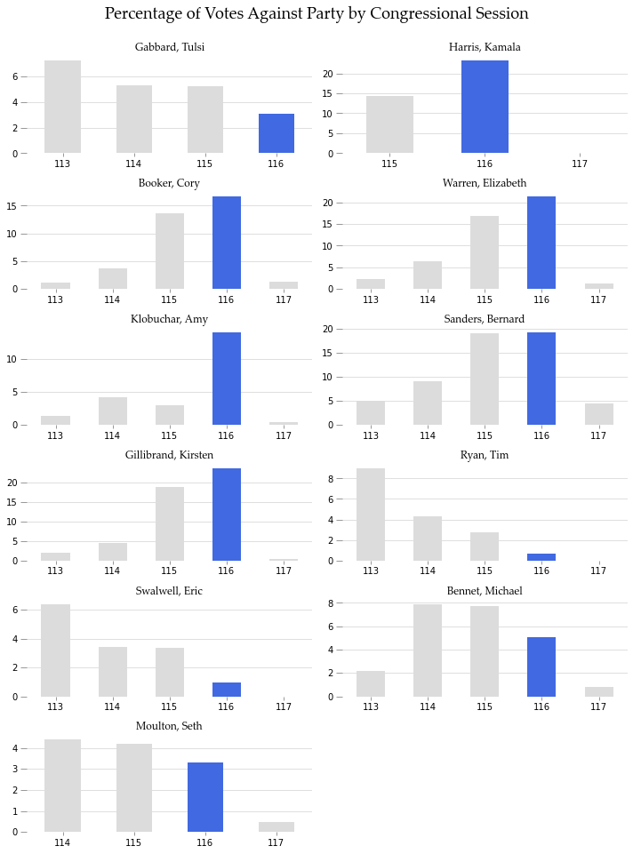

```python
fig = graph_vote_stats(pres_cong_members, "votes_against_party_pct", member_names)
fig.suptitle("Percentage of Votes Against Party by Congressional Session", fontname="Palatino Linotype", fontsize=18)
fig.tight_layout(rect=rect)
# fig.savefig(image_path + "against_party_votes.png", dpi=200)
```

Again, use above graph created with function.

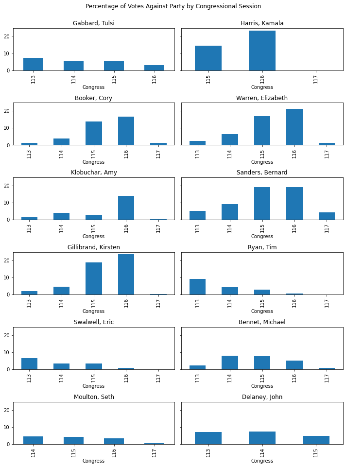

```python
fig, ax = plt.subplots(6, 2, figsize=(10, 14), sharey=True)
for name, a in zip(list(member_ids.index), ax.flatten()):
    (pres_cong_members.loc[name, ["congress", "votes_against_party_pct"]].reset_index("full_name", drop=True)
     .plot(x="congress", y="votes_against_party_pct", ax=a, kind="bar", title=name, legend=False,
          xlabel="Congress")
    )
fig.suptitle("Percentage of Votes Against Party by Congressional Session")
fig.tight_layout(rect=rect)
# fig.delaxes(ax.flatten()[-1])
# fig.savefig(image_path + "against_party_votes.png", dpi=200)
```

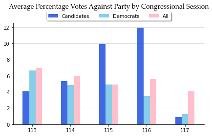

```python
all_votes_against_party = (congress_members_more.groupby("congress")["votes_against_party_pct"].mean()
                           .rename("All"))
dem_votes_against_party = (not_pres_cong_members.groupby(["congress", "party"])["votes_against_party_pct"].mean().loc[:, "D", :]
                           .rename("Democrats"))
cand_votes_against_party = (pres_cong_members.groupby("congress")["votes_against_party_pct"].mean()
                            .rename("Candidates"))
# all_votes_against_party.to_frame().join(dem_votes_against_party.to_frame).join(cand_votes_against_party.to_frame)
fig, ax = plt.subplots()
(pd.concat([cand_votes_against_party, dem_votes_against_party, all_votes_against_party], axis=1)
 .plot(ax=ax, kind="bar", color=["royalblue", "skyblue", "pink"], rot=0,
       xlabel="", ylabel="", zorder=2)
)
ax.grid(axis="y", zorder=0, alpha=0.5)

# make legend look nice
handles, labels = ax.get_legend_handles_labels()
# fig.subplots_adjust(bottom=0, top=0.05)
ax.legend(handles, labels, ncol=3, loc="center", bbox_to_anchor=(0.5, 1.07), fancybox=True, shadow=True)
ax.set_title("Average Percentage Votes Against Party by Congressional Session", pad=30, fontname="Palatino Linotype", fontsize=14)

remove_spines(ax)
fig.tight_layout()
# fig.savefig(image_path + "against_party_summary.png", dpi=200)
```

Now get avg percentage votes against party for House and Senate (should prob make an agg graphing function)

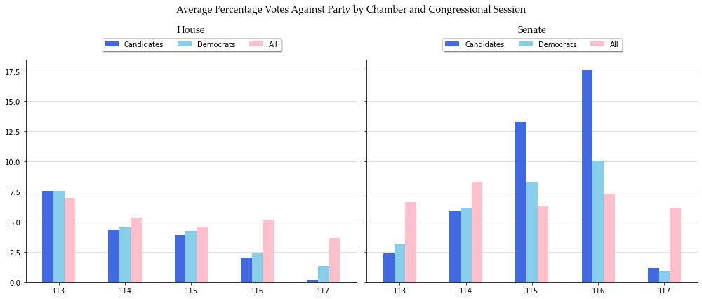

```python
fig, ax = plt.subplots(1, 2, figsize=(14, 6), sharey=True)
cong_chamber_votes_against = (congress_members_more.groupby(["short_title", "congress"])["votes_against_party_pct"].mean()
                              .loc[["Rep.", "Sen."], :, :].rename("All"))
dem_chamber_votes_against = (not_pres_cong_members.groupby(["party", "short_title", "congress"])["votes_against_party_pct"].mean()
                              .loc["D", ["Rep.", "Sen."], :, :].rename("Democrats"))["D"]
cand_chamber_votes_against = (pres_cong_members.groupby(["short_title", "congress"])["votes_against_party_pct"].mean()
                              .rename("Candidates"))
both_chamber_votes_against = pd.concat([cand_chamber_votes_against, dem_chamber_votes_against, cong_chamber_votes_against], axis=1)
chambers = ["House", "Senate"]
for i, c in enumerate(["Rep.", "Sen."]):
    a = ax[i]
    both_chamber_votes_against.loc[c].plot(ax=a, kind="bar", color=["royalblue", "skyblue", "pink"], rot=0,
       xlabel="", ylabel="", zorder=2)
    a.grid(axis="y", zorder=0, alpha=0.5)

    # make legend look nice
    handles, labels = a.get_legend_handles_labels()
    # fig.subplots_adjust(bottom=0, top=0.05)
    a.legend(handles, labels, ncol=3, loc="center", bbox_to_anchor=(0.5, 1.07), fancybox=True, shadow=True)
    a.set_title(chambers[i], pad=40, fontname="Palatino Linotype", fontsize=14)
    remove_spines(a)
fig.suptitle("Average Percentage Votes Against Party by Chamber and Congressional Session", fontname="Palatino Linotype", fontsize=14)
fig.tight_layout()
# fig.savefig(image_path + "chamber_against_party_summary.png", dpi=200)
```

### Campaign Finance

Measuring money raised both for congressional runs and for presidential runs for each of the candidates.

Using [FEC API](https://api.open.fec.gov/developers/).

Note: "If a person runs for several offices, that person will have separate candidate IDs for each office."

```python
fec_api_key = "api-key-here"
def fec_data(url):
    return requests.get(url).json()
```

```python
# because Tim Ryan doesn't appear, use his long name
cand_names_long = list(cand_names.copy())
cand_names_long.remove("Ryan, Tim")
cand_names_long.append("Ryan, Timothy")

def cand_fec_data(cand_names):
    dfs = []
    for name in cand_names:
        cand_name = ("%20").join(name.split(", "))
        url = "https://api.open.fec.gov/v1/candidates/search/?sort=name&api_key=" + fec_api_key + "&sort_null_only=false&sort_hide_null=false&q=" + cand_name + "&page=1&per_page=20&sort_nulls_last=false"
        df = pd.DataFrame(fec_data(url)["results"])
        dfs.append(df)
    return pd.concat(dfs)

cand_fec_df = cand_fec_data(cand_names_long)
cand_fec_df.head()
```

|  | election_districts | first_file_date | incumbent_challenge_full | name | candidate_id | party | state | cycles | last_file_date | incumbent_challenge | ... | federal_funds_flag | candidate_status | district | election_years | has_raised_funds | last_f2_date | candidate_inactive | load_date | district_number | party_full |
| --- | --- | --- | --- | --- | --- | --- | --- | --- | --- | --- | --- | --- | --- | --- | --- | --- | --- | --- | --- | --- | --- |
| 0 | [02, 02, 02, 02, 02] | 2011-06-10 | Incumbent | GABBARD, TULSI | H2HI02508 | DEM | HI | [2012, 2014, 2016, 2018, 2020, 2022] | 2018-11-22 | I | ... | False | P | 02 | [2012, 2014, 2016, 2018, 2020] | True | 2018-11-22 | False | 2021-03-29T15:22:09+00:00 | 2 | DEMOCRATIC PARTY |
| 1 | [00] | 2019-01-11 | Challenger | GABBARD, TULSI | P00009183 | DEM | US | [2020, 2022] | 2019-01-11 | C | ... | False | P | 00 | [2020] | False | 2019-01-11 | False | 2021-05-25T06:34:23+00:00 | 0 | DEMOCRATIC PARTY |
| 0 | [00, 00] | 2015-01-22 | Incumbent | HARRIS, KAMALA D | S6CA00584 | DEM | CA | [2016, 2018, 2020, 2022] | 2020-10-20 | I | ... | False | C | 00 | [2016, 2022] | True | 2020-10-20 | True | 2021-05-25T06:34:23+00:00 | 0 | DEMOCRATIC PARTY |
| 1 | [00] | 2019-01-21 | Challenger | HARRIS, KAMALA D. | P00009423 | DEM | US | [2020, 2022] | 2019-01-21 | C | ... | False | P | 00 | [2020] | True | 2019-01-21 | False | 2021-05-25T06:34:23+00:00 | 0 | DEMOCRATIC PARTY |
| 0 | [00] | 2019-02-01 | Challenger | BOOKER, CORY A. | P00009795 | DEM | US | [2020, 2022] | 2019-02-01 | C | ... | False | P | 00 | [2020] | True | 2019-02-01 | False | 2021-05-25T06:34:23+00:00 | 0 | DEMOCRATIC PARTY |

5 rows × 25 columns

First, look at presidential data.

```python
pres_cand_df = cand_fec_df[(cand_fec_df["office"] == "P") & (cand_fec_df["party"] == "DEM")]
pres_cand_ids = pres_cand_df[["candidate_id", "name"]]
pres_cand_ids
```

|  | candidate_id | name |
| --- | --- | --- |
| 1 | P00009183 | GABBARD, TULSI |
| 1 | P00009423 | HARRIS, KAMALA D. |
| 0 | P00009795 | BOOKER, CORY A. |
| 0 | P00009621 | WARREN, ELIZABETH |
| 1 | P80006117 | KLOBUCHAR, AMY J. |
| 1 | P60007168 | SANDERS, BERNARD |
| 0 | P00009290 | GILLIBRAND, KIRSTEN |
| 1 | P00011312 | SWALWELL, ERIC MICHAEL |
| 0 | P00011833 | BENNET, MICHAEL F. |
| 1 | P00011866 | MOULTON, SETH |
| 1 | P00006213 | DELANEY, JOHN K. |
| 3 | P00011338 | RYAN, TIMOTHY J. |

```python
def fec_cand_info(cand_ids):
    """
    Get campaign funds info given FEC candidate id Series w/ candidate id and corresponding name.
    """
    dfs = []
    cand_id_list = list(cand_ids["candidate_id"])
    for cand_id in cand_id_list:
        url = "https://api.open.fec.gov/v1/candidate/" + cand_id + "/totals/?sort_hide_null=false&api_key=" + fec_api_key + "&page=1&sort_null_only=false&per_page=20&sort_nulls_last=false&sort=-cycle"
        df = pd.DataFrame(fec_data(url)["results"])
        dfs.append(df)
    dfs_concat = pd.concat(dfs).merge(cand_ids, on="candidate_id")
    # make cycle years into datetime
    dfs_concat["cycle"] = dfs_concat["cycle"].apply(pd.to_datetime, format="%Y")
    return dfs_concat
cand_fec_money = fec_cand_info(pres_cand_ids)
cand_fec_money
```

|  | offsets_to_fundraising_expenditures | offsets_to_legal_accounting | election_full | fundraising_disbursements | other_receipts | loans_received_from_candidate | transfers_to_other_authorized_committee | candidate_election_year | operating_expenditures | last_debts_owed_by_committee | ... | contributions | individual_itemized_contributions | coverage_start_date | repayments_loans_made_by_candidate | candidate_contribution | last_cash_on_hand_end_period | net_contributions | net_operating_expenditures | transfers_from_affiliated_committee | name |
| --- | --- | --- | --- | --- | --- | --- | --- | --- | --- | --- | --- | --- | --- | --- | --- | --- | --- | --- | --- | --- | --- |
| 0 | 0.0 | 0.0 | True | 0.0 | 488195.46 | 0.0 | 38000.00 | 2020.0 | 4.108128e+07 | 90130.84 | ... | 3.962963e+07 | 23724637.0 | 2019-01-21T00:00:00+00:00 | 0.0 | 0.00 | 250163.26 | 3.816588e+07 | 4.076946e+07 | 2651337.47 | HARRIS, KAMALA D. |
| 1 | 0.0 | 0.0 | False | 0.0 | 401.91 | 0.0 | 0.00 | NaN | 8.264550e+04 | 0.00 | ... | 0.000000e+00 | 0.0 | 2021-01-01T00:00:00+00:00 | 0.0 | 0.00 | 167919.67 | 3.952809e+07 | 1.034856e+06 | 0.00 | HARRIS, KAMALA D. |
| 2 | 0.0 | 0.0 | False | 0.0 | 488195.46 | 0.0 | 38000.00 | 2020.0 | 4.108128e+07 | 90130.84 | ... | 3.962963e+07 | 23724637.0 | 2019-01-21T00:00:00+00:00 | 0.0 | 0.00 | 250163.26 | 3.816588e+07 | 4.076946e+07 | 2651337.47 | HARRIS, KAMALA D. |
| 3 | 0.0 | 0.0 | True | 0.0 | 195119.33 | 0.0 | 217756.03 | 2020.0 | 2.530290e+07 | 785889.53 | ... | 2.298137e+07 | 15106972.0 | 2019-01-01T00:00:00+00:00 | 0.0 | 0.00 | 53630.33 | 2.243725e+07 | 2.512709e+07 | 2740000.00 | BOOKER, CORY A. |
| 4 | 0.0 | 0.0 | False | 0.0 | 0.00 | 0.0 | 0.00 | NaN | 5.406056e+04 | 785889.53 | ... | 3.420000e+04 | 22200.0 | 2021-01-01T00:00:00+00:00 | 0.0 | 0.00 | 30344.35 | 2.247120e+07 | 2.518670e+07 | 0.00 | BOOKER, CORY A. |
| 5 | 0.0 | 0.0 | False | 0.0 | 195119.33 | 0.0 | 217756.03 | 2020.0 | 2.530290e+07 | 785889.53 | ... | 2.298137e+07 | 15106972.0 | 2019-01-01T00:00:00+00:00 | 0.0 | 0.00 | 53630.33 | 2.243725e+07 | 2.512709e+07 | 2740000.00 | BOOKER, CORY A. |
| 6 | 0.0 | 0.0 | True | 0.0 | 1873697.92 | 400000.0 | 515782.33 | 2020.0 | 1.289922e+08 | 439337.03 | ... | 1.159029e+08 | 49372532.0 | 2019-01-01T00:00:00+00:00 | 400000.0 | 5777.50 | 178499.13 | 1.148919e+08 | 1.260027e+08 | 10415000.00 | WARREN, ELIZABETH |
| 7 | 0.0 | 0.0 | False | 0.0 | 0.11 | 0.0 | 0.00 | NaN | 1.604951e+05 | 318640.23 | ... | 4.740200e+03 | 4300.0 | 2021-01-01T00:00:00+00:00 | 0.0 | 0.00 | 22928.76 | 1.158989e+08 | 3.731797e+05 | 0.00 | WARREN, ELIZABETH |
| 8 | 0.0 | 0.0 | False | 0.0 | 1873697.92 | 400000.0 | 515782.33 | 2020.0 | 1.289922e+08 | 439337.03 | ... | 1.159029e+08 | 49372532.0 | 2019-01-01T00:00:00+00:00 | 400000.0 | 5777.50 | 178499.13 | 1.148919e+08 | 1.260027e+08 | 10415000.00 | WARREN, ELIZABETH |
| 9 | 110.1 | 0.0 | True | 0.0 | 2394.75 | 0.0 | 1668340.40 | 2020.0 | 5.179877e+07 | 0.00 | ... | 4.989640e+07 | 27621173.0 | 2019-02-07T00:00:00+00:00 | 0.0 | 0.00 | 47746.78 | 4.884429e+07 | 5.070368e+07 | 3575275.00 | KLOBUCHAR, AMY J. |
| 10 | 0.0 | 0.0 | False | 0.0 | 0.00 | 0.0 | 0.00 | NaN | 1.400582e+04 | 0.00 | ... | 0.000000e+00 | 0.0 | 2021-01-01T00:00:00+00:00 | 0.0 | 0.00 | 33706.41 | 4.884423e+07 | 5.071766e+07 | 0.00 | KLOBUCHAR, AMY J. |
| 11 | 110.1 | 0.0 | False | 0.0 | 2394.75 | 0.0 | 1668340.40 | 2020.0 | 5.179877e+07 | 0.00 | ... | 4.989640e+07 | 27621173.0 | 2019-02-07T00:00:00+00:00 | 0.0 | 0.00 | 47746.78 | 4.884429e+07 | 5.070368e+07 | 3575275.00 | KLOBUCHAR, AMY J. |
| 12 | 0.0 | 0.0 | True | 0.0 | 76977.37 | 0.0 | 0.00 | 2016.0 | 2.268271e+08 | 449409.01 | ... | 2.318206e+08 | 97145068.0 | 2015-04-01T00:00:00+00:00 | 0.0 | 0.00 | 5455167.90 | -1.148250e+04 | -7.338586e+05 | 1500000.00 | SANDERS, BERNARD |
| 13 | 0.0 | 0.0 | True | 0.0 | 428105.08 | 0.0 | 6601500.00 | 2020.0 | 2.107728e+08 | 0.00 | ... | 2.025692e+08 | 87745795.0 | 2017-01-01T00:00:00+00:00 | 0.0 | 0.00 | 2650205.79 | 1.981181e+08 | 2.067130e+08 | 12701500.00 | SANDERS, BERNARD |
| 14 | 0.0 | 0.0 | False | 0.0 | 9293.04 | 0.0 | 0.00 | NaN | 1.211406e+06 | 0.00 | ... | 0.000000e+00 | 0.0 | 2021-01-01T00:00:00+00:00 | 0.0 | 0.00 | 1683386.52 | 1.980077e+08 | 2.076330e+08 | 0.00 | SANDERS, BERNARD |
| 15 | 0.0 | 0.0 | False | 0.0 | 354326.40 | 0.0 | 6601500.00 | 2020.0 | 2.099544e+08 | 0.00 | ... | 2.025692e+08 | 87745795.0 | 2019-01-01T00:00:00+00:00 | 0.0 | 0.00 | 2650205.79 | 1.981181e+08 | 2.067130e+08 | 12701500.00 | SANDERS, BERNARD |
| 16 | 0.0 | 0.0 | False | 0.0 | 73778.68 | 0.0 | 0.00 | 2020.0 | 8.183134e+05 | 0.00 | ... | 1.000000e+01 | 0.0 | 2017-01-01T00:00:00+00:00 | 0.0 | 0.00 | 4743726.76 | -2.161819e+04 | 1.885156e+04 | 0.00 | SANDERS, BERNARD |
| 17 | 0.0 | 0.0 | False | 0.0 | 76977.37 | 0.0 | 0.00 | 2016.0 | 2.268271e+08 | 449409.01 | ... | 2.318206e+08 | 97145068.0 | 2015-04-01T00:00:00+00:00 | 0.0 | 0.00 | 5455167.90 | -1.148250e+04 | -7.338586e+05 | 1500000.00 | SANDERS, BERNARD |
| 18 | 0.0 | 0.0 | True | 0.0 | 17645.57 | 0.0 | 1372417.89 | 2020.0 | 1.441638e+07 | 0.00 | ... | 6.285792e+06 | 4299445.0 | 2019-01-01T00:00:00+00:00 | 0.0 | 77.76 | 84388.65 | 6.206054e+06 | 1.436541e+07 | 9600000.00 | GILLIBRAND, KIRSTEN |
| 19 | 0.0 | 0.0 | False | 0.0 | 3.04 | 0.0 | 0.00 | NaN | 1.114698e+04 | 0.00 | ... | 0.000000e+00 | 0.0 | 2021-01-01T00:00:00+00:00 | 0.0 | 0.00 | 78609.89 | 6.206054e+06 | 1.437120e+07 | 0.00 | GILLIBRAND, KIRSTEN |
| 20 | 0.0 | 0.0 | False | 0.0 | 17645.57 | 0.0 | 1372417.89 | 2020.0 | 1.441638e+07 | 0.00 | ... | 6.285792e+06 | 4299445.0 | 2019-01-01T00:00:00+00:00 | 0.0 | 77.76 | 84388.65 | 6.206054e+06 | 1.436541e+07 | 9600000.00 | GILLIBRAND, KIRSTEN |
| 21 | 0.0 | 0.0 | True | 0.0 | 0.00 | 0.0 | 33745.17 | 2020.0 | 2.509661e+06 | 0.00 | ... | 8.928725e+05 | 551987.0 | 2019-02-07T00:00:00+00:00 | 0.0 | 0.00 | 0.00 | 8.477721e+05 | 2.497677e+06 | 1700000.00 | SWALWELL, ERIC MICHAEL |
| 22 | 0.0 | 0.0 | False | 0.0 | 0.00 | 0.0 | 33745.17 | 2020.0 | 2.509661e+06 | 0.00 | ... | 8.928725e+05 | 551987.0 | 2019-02-07T00:00:00+00:00 | 0.0 | 0.00 | 0.00 | 8.477721e+05 | 2.497677e+06 | 1700000.00 | SWALWELL, ERIC MICHAEL |
| 23 | 0.0 | 0.0 | True | 0.0 | 0.00 | 0.0 | 55401.46 | 2020.0 | 7.349015e+06 | 0.00 | ... | 6.803046e+06 | 4462562.0 | 2019-04-01T00:00:00+00:00 | 0.0 | 2800.00 | 3864.37 | 0.000000e+00 | 9.752520e+03 | 700000.00 | BENNET, MICHAEL F. |
| 24 | 0.0 | 0.0 | False | 0.0 | 0.00 | 0.0 | 0.00 | NaN | 2.499250e+03 | 0.00 | ... | 0.000000e+00 | 0.0 | 2021-01-01T00:00:00+00:00 | 0.0 | 0.00 | 1575.40 | -9.992580e+04 | 7.329709e+06 | 0.00 | BENNET, MICHAEL F. |
| 25 | 0.0 | 0.0 | False | 0.0 | 0.00 | 0.0 | 55401.46 | 2020.0 | 7.349015e+06 | 0.00 | ... | 6.803046e+06 | 4462562.0 | 2019-04-01T00:00:00+00:00 | 0.0 | 2800.00 | 3864.37 | 0.000000e+00 | 9.752520e+03 | 700000.00 | BENNET, MICHAEL F. |
| 26 | 0.0 | 0.0 | True | 0.0 | 2.49 | 40000.0 | 296488.63 | 2020.0 | 1.963954e+06 | 0.00 | ... | 1.499861e+06 | 1157076.0 | 2019-04-01T00:00:00+00:00 | 40000.0 | 0.00 | 960.16 | 1.432219e+06 | 1.905602e+06 | 918579.19 | MOULTON, SETH |
| 27 | 0.0 | 0.0 | False | 0.0 | 0.00 | 0.0 | 0.00 | NaN | 8.410840e+03 | 0.00 | ... | 0.000000e+00 | 0.0 | 2021-01-01T00:00:00+00:00 | 0.0 | 0.00 | 0.00 | 1.432219e+06 | 1.914013e+06 | 7450.68 | MOULTON, SETH |
| 28 | 0.0 | 0.0 | False | 0.0 | 2.49 | 40000.0 | 296488.63 | 2020.0 | 1.963954e+06 | 0.00 | ... | 1.499861e+06 | 1157076.0 | 2019-04-01T00:00:00+00:00 | 40000.0 | 0.00 | 960.16 | 1.432219e+06 | 1.905602e+06 | 918579.19 | MOULTON, SETH |
| 29 | 0.0 | 0.0 | True | 0.0 | 0.00 | 25245000.0 | 60000.00 | 2020.0 | 1.424290e+07 | 1493250.00 | ... | 3.917858e+06 | 2236208.0 | 2017-01-01T00:00:00+00:00 | 15000000.0 | 1169076.55 | 12026.58 | 3.835781e+06 | 1.400407e+07 | 0.00 | DELANEY, JOHN K. |
| 30 | 0.0 | 0.0 | False | 0.0 | 0.00 | 0.0 | 0.00 | NaN | 7.814220e+03 | 1493250.00 | ... | 0.000000e+00 | 0.0 | 2021-01-01T00:00:00+00:00 | 0.0 | 0.00 | 5442.08 | 3.835781e+06 | 1.401066e+07 | 0.00 | DELANEY, JOHN K. |
| 31 | 0.0 | 0.0 | False | 0.0 | 0.00 | 20665000.0 | 0.00 | 2020.0 | 8.468338e+06 | 1493250.00 | ... | 2.397373e+06 | 1002661.0 | 2019-01-01T00:00:00+00:00 | 15000000.0 | 1089076.55 | 12026.58 | 3.835781e+06 | 1.400407e+07 | 0.00 | DELANEY, JOHN K. |
| 32 | 0.0 | 0.0 | False | 0.0 | 0.00 | 4580000.0 | 60000.00 | 2020.0 | 5.774562e+06 | 5743250.00 | ... | 1.520485e+06 | 1233547.0 | 2017-01-01T00:00:00+00:00 | 0.0 | 80000.00 | 268248.08 | 1.500334e+06 | 5.783051e+06 | 0.00 | DELANEY, JOHN K. |
| 33 | 0.0 | 0.0 | True | 0.0 | 0.00 | 0.0 | 23179.05 | 2020.0 | 1.293955e+06 | 0.00 | ... | 1.340680e+06 | 850050.0 | 2019-04-01T00:00:00+00:00 | 0.0 | 0.00 | 303.76 | 1.318567e+06 | 1.293389e+06 | 0.00 | RYAN, TIMOTHY J. |
| 34 | 0.0 | 0.0 | False | 0.0 | 0.00 | 0.0 | 23179.05 | 2020.0 | 1.293955e+06 | 0.00 | ... | 1.340680e+06 | 850050.0 | 2019-04-01T00:00:00+00:00 | 0.0 | 0.00 | 303.76 | 1.318567e+06 | 1.293389e+06 | 0.00 | RYAN, TIMOTHY J. |

35 rows × 47 columns

Select rows by candidate (and see if any repeating)

```python
# only select rows with full election (so there's no double counting)
cand_fec_money = cand_fec_money[cand_fec_money["election_full"] == True].set_index("name")
# drop Bernie's 2016 run
cand_fec_money = cand_fec_money[cand_fec_money["last_report_year"] != 2016]
```

Plot total individual contributions just to see

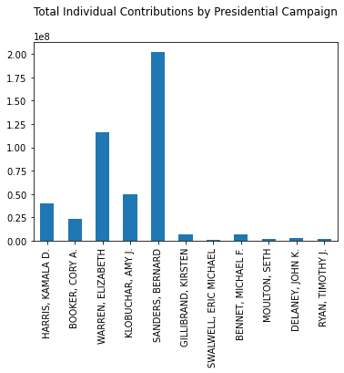

```python
fig, ax = plt.subplots()
# cand_fec_money
cand_fec_money["individual_contributions"].plot(ax=ax, kind="bar", xlabel="")
ax.set_title("Total Individual Contributions by Presidential Campaign", pad=30)
```

Next, look at congressional fundraising data for these candidates

```python
congress_fec_df = cand_fec_df[(cand_fec_df["office"] == "H") | (cand_fec_df["office"] == "S")]
congress_fec_df = congress_fec_df[congress_fec_df["incumbent_challenge"] == "I"] # get id of those in office, not those running with similar names
congress_fec_df.head()
```

|  | election_districts | first_file_date | incumbent_challenge_full | name | candidate_id | party | state | cycles | last_file_date | incumbent_challenge | ... | federal_funds_flag | candidate_status | district | election_years | has_raised_funds | last_f2_date | candidate_inactive | load_date | district_number | party_full |
| --- | --- | --- | --- | --- | --- | --- | --- | --- | --- | --- | --- | --- | --- | --- | --- | --- | --- | --- | --- | --- | --- |
| 0 | [02, 02, 02, 02, 02] | 2011-06-10 | Incumbent | GABBARD, TULSI | H2HI02508 | DEM | HI | [2012, 2014, 2016, 2018, 2020, 2022] | 2018-11-22 | I | ... | False | P | 02 | [2012, 2014, 2016, 2018, 2020] | True | 2018-11-22 | False | 2021-03-29T15:22:09+00:00 | 2 | DEMOCRATIC PARTY |
| 0 | [00, 00] | 2015-01-22 | Incumbent | HARRIS, KAMALA D | S6CA00584 | DEM | CA | [2016, 2018, 2020, 2022] | 2020-10-20 | I | ... | False | C | 00 | [2016, 2022] | True | 2020-10-20 | True | 2021-05-25T06:34:23+00:00 | 0 | DEMOCRATIC PARTY |
| 1 | [00, 00, 00] | 2013-05-13 | Incumbent | BOOKER, CORY A. | S4NJ00185 | DEM | NJ | [2014, 2016, 2018, 2020, 2022] | 2021-02-04 | I | ... | False | C | 00 | [2014, 2020, 2026] | True | 2021-02-04 | False | 2021-05-25T06:34:23+00:00 | 0 | DEMOCRATIC PARTY |
| 1 | [00, 00, 00] | 2011-08-19 | Incumbent | WARREN, ELIZABETH | S2MA00170 | DEM | MA | [2012, 2014, 2016, 2018, 2020, 2022] | 2020-03-23 | I | ... | False | F | 00 | [2012, 2018, 2024] | True | 2020-03-23 | False | 2021-05-25T06:34:23+00:00 | 0 | DEMOCRATIC PARTY |
| 0 | [00, 00, 00, 00] | 2005-03-01 | Incumbent | KLOBUCHAR, AMY | S6MN00267 | DFL | MN | [2006, 2008, 2010, 2012, 2014, 2016, 2018, 202... | 2020-03-03 | I | ... | False | C | 00 | [2006, 2012, 2018, 2024] | True | 2020-03-03 | False | 2021-05-25T06:34:23+00:00 | 0 | DEMOCRATIC-FARMER-LABOR |

5 rows × 25 columns

*Note: Bernie Sanders is the only one of these candidates to have been in both chambers of Congress*

Now, isolate each candidate's congressional campaign candidate id (and get office).

```python
cong_cand_ids = congress_fec_df[["candidate_id", "name", "office", "election_years"]]
cong_cand_ids
```

|  | candidate_id | name | office | election_years |
| --- | --- | --- | --- | --- |
| 0 | H2HI02508 | GABBARD, TULSI | H | [2012, 2014, 2016, 2018, 2020] |
| 0 | S6CA00584 | HARRIS, KAMALA D | S | [2016, 2022] |
| 1 | S4NJ00185 | BOOKER, CORY A. | S | [2014, 2020, 2026] |
| 1 | S2MA00170 | WARREN, ELIZABETH | S | [2012, 2018, 2024] |
| 0 | S6MN00267 | KLOBUCHAR, AMY | S | [2006, 2012, 2018, 2024] |
| 0 | H8VT01016 | SANDERS, BERNARD | H | [1988, 1990, 1992, 1994, 1996, 1998, 2000, 200... |
| 2 | S4VT00033 | SANDERS, BERNARD | S | [1976, 2006, 2012, 2018, 2024] |
| 1 | S0NY00410 | GILLIBRAND, KIRSTEN | S | [2010, 2012, 2018, 2024] |
| 0 | H2CA15094 | SWALWELL, ERIC MICHAEL | H | [2012, 2014, 2016, 2018, 2020, 2022] |
| 1 | S0CO00211 | BENNET, MICHAEL F. | S | [2010, 2016, 2022] |
| 0 | H4MA06090 | MOULTON, SETH | H | [2014, 2016, 2018, 2020, 2022] |
| 0 | H2MD06195 | DELANEY, JOHN K | H | [2012, 2014, 2016, 2018] |
| 0 | H2OH17109 | RYAN, TIMOTHY | H | [2002, 2004, 2006, 2008, 2010, 2012, 2014, 201... |

Get congressional FEC info for each 2 year cycle for each candidate (also adds office to df b/c it's in cong_cand_ids).

```python
cong_cand_fec_money = fec_cand_info(cong_cand_ids)
cong_cand_fec_money = cong_cand_fec_money[cong_cand_fec_money["election_full"] == True].set_index("name")
cong_cand_fec_money.head()
```

| name | total_offsets_to_operating_expenditures | individual_contributions | last_debts_owed_to_committee | net_operating_expenditures | contributions | last_debts_owed_by_committee | coverage_end_date | loan_repayments | other_disbursements | refunded_individual_contributions | ... | receipts | refunded_other_political_committee_contributions | operating_expenditures | transfers_from_other_authorized_committee | all_other_loans | last_report_year | exempt_legal_accounting_disbursement | last_report_type_full | office | election_years |
| --- | --- | --- | --- | --- | --- | --- | --- | --- | --- | --- | --- | --- | --- | --- | --- | --- | --- | --- | --- | --- | --- |
| GABBARD, TULSI | 0.0 | 1299287.68 | 0.0 | 1306629.57 | 1684901.87 | 44000.0 | 2012-12-31T00:00:00+00:00 | 64000.0 | 105000.0 | 1989.00 | ... | 1828589.91 | 2900.00 | 1342317.61 | 0.00 | 0.0 | 2012 | 0.0 | YEAR-END | H | [2012, 2014, 2016, 2018, 2020] |
| GABBARD, TULSI | 0.0 | 1205276.06 | 0.0 | 671595.36 | 1656033.06 | 0.0 | 2014-12-31T00:00:00+00:00 | 44000.0 | 158400.0 | 4485.65 | ... | 1674001.78 | 0.00 | 684199.41 | 3600.00 | 0.0 | 2014 | 0.0 | YEAR-END | H | [2012, 2014, 2016, 2018, 2020] |
| GABBARD, TULSI | 0.0 | 1734809.33 | 0.0 | 1096702.44 | 2211883.14 | 0.0 | 2016-12-31T00:00:00+00:00 | 0.0 | 152900.0 | 23107.48 | ... | 2262362.51 | 5000.00 | 1110655.00 | 34605.95 | 0.0 | 2016 | 0.0 | YEAR-END | H | [2012, 2014, 2016, 2018, 2020] |
| GABBARD, TULSI | 0.0 | 1383619.18 | 0.0 | 1372243.70 | 1410356.85 | 0.0 | 2018-12-31T00:00:00+00:00 | 0.0 | 51385.0 | 13080.95 | ... | 1421020.43 | 11237.67 | 1376398.96 | 233.41 | 0.0 | 2018 | 0.0 | YEAR-END | H | [2012, 2014, 2016, 2018, 2020] |
| GABBARD, TULSI | 0.0 | 82761.58 | 0.0 | 112132.74 | 82761.58 | 0.0 | 2020-12-31T00:00:00+00:00 | 0.0 | 4000.0 | 8571.00 | ... | 737136.68 | 0.00 | 112287.61 | 653000.00 | 0.0 | 2020 | 0.0 | YEAR-END | H | [2012, 2014, 2016, 2018, 2020] |

5 rows × 50 columns

Now, graph each candidate's congressional fundraising numbers.

First, aggregate measures; then, for each cycle. Finally, compare with presidential fundraising and get a ratio of congressional fundraising (an aggregate or most recent or both?) to presidential fundraising.

*Need to make sure no important data is missed*

```
name
BENNET, MICHAEL F.        7.957055e+06
BOOKER, CORY A.           8.846476e+06
DELANEY, JOHN K           1.184045e+06
GABBARD, TULSI            1.141151e+06
GILLIBRAND, KIRSTEN       1.066369e+07
HARRIS, KAMALA D          1.064049e+07
KLOBUCHAR, AMY            5.960162e+06
MOULTON, SETH             1.427769e+06
RYAN, TIMOTHY             5.420461e+05
SANDERS, BERNARD          3.190763e+06
SWALWELL, ERIC MICHAEL    1.324854e+06
WARREN, ELIZABETH         2.617972e+07
Name: individual_contributions, dtype: float64
```

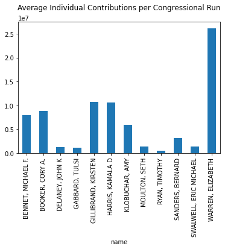

```python
fig, ax = plt.subplots()
agg_stat_by_campaign = cong_cand_fec_money.groupby(["name"]).mean()["individual_contributions"]
agg_stat_by_campaign.plot(ax=ax, kind="bar")
ax.set_title("Average Individual Contributions per Congressional Run", pad=20)
agg_stat_by_campaign
```

Note: sorting by last_report_year is better than cycle because it splits House into 2 years and Senate into 6.

If candidate is currently in office and planning on running in the next cycle for a congressional seat, 2021 will be on the bar graph.

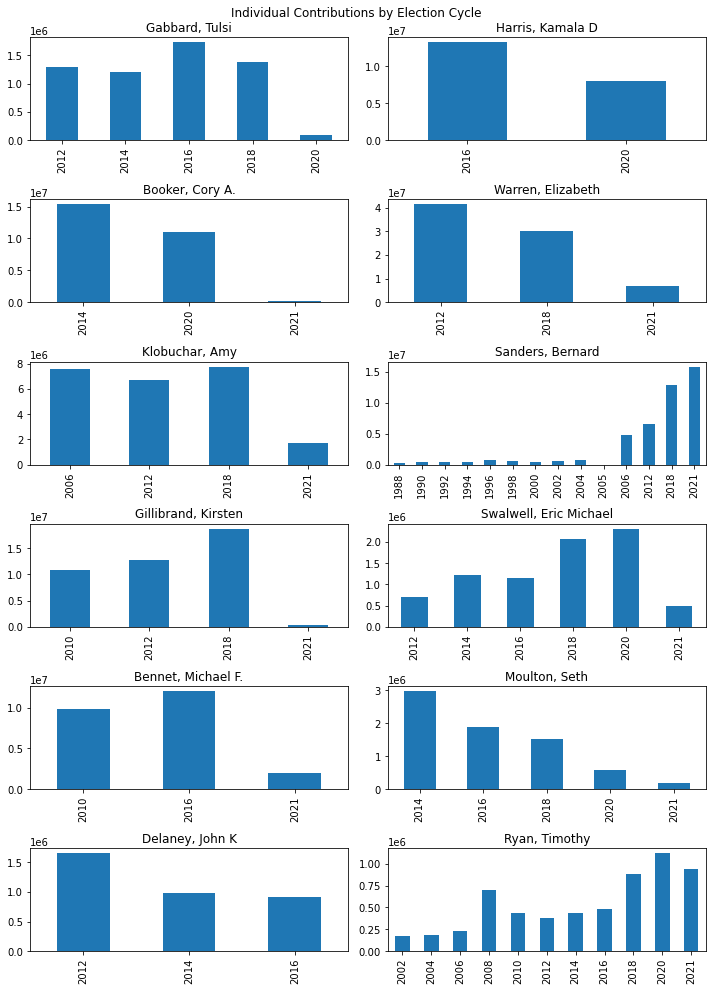

```python
fig, ax = plt.subplots(6, 2, figsize=(10, 14))
# cong_by_cycle = cong_cand_fec_money.groupby(["name", "cycle"]).sum()["net_operating_expenditures"].reset_index()
# cong_by_cycle["cycle"] = cong_by_cycle["cycle"].map(lambda s: s.strftime("%Y"))
stat_df = cong_cand_fec_money.reset_index().set_index(["name", "last_report_year"])["individual_contributions"].sort_index(level=1)
# stat_df
for name, a in zip(cong_cand_ids["name"].unique(), ax.flatten()):
    stat_df.loc[name].plot(ax=a, kind="bar", title=name.title(), xlabel="")
fig.suptitle("Individual Contributions by Election Cycle")
fig.tight_layout()
```

### Preliminary Fundraising Analysis

**These results aren't finalized; they are points for future analysis.**

Compare congressional fundraising to presidential fundraising per election cycle (i.e. per total of 2 years for House and 6 years for Senate -- get most recent term's total fundraising)

Compare total presidential fundraising to total congressional fundraising. Then, compare total presidential fundraising to total congressional fundraising per election year.

*Note: Tulsi Gabbard is excluded below; need to address in future*

```python
cand_fec_money.info()
# cand_fec_money["contributions"]
# cong_cand_fec_money["other_political_committee_contributions"]
```

```
<class 'pandas.core.frame.DataFrame'>
Index: 11 entries, HARRIS, KAMALA D. to RYAN, TIMOTHY J.
Data columns (total 46 columns):
 #   Column                                            Non-Null Count  Dtype
---  ------                                            --------------  -----
 0   offsets_to_fundraising_expenditures               11 non-null     float64
 1   offsets_to_legal_accounting                       11 non-null     float64
 2   election_full                                     11 non-null     bool
 3   fundraising_disbursements                         11 non-null     float64
 4   other_receipts                                    11 non-null     float64
 5   loans_received_from_candidate                     11 non-null     float64
 6   transfers_to_other_authorized_committee           11 non-null     float64
 7   candidate_election_year                           11 non-null     float64
 8   operating_expenditures                            11 non-null     float64
 9   last_debts_owed_by_committee                      11 non-null     float64
```

[output cut: 38 more lines]

```python
def remove_middle_initial(x):
    """
    Removes middle initial (either followed by a "." or not) and returns result.
    """
    return re.sub(r"\s[A-Z]{1,2}\.$|\s[A-Z]$", "", x).title()

def compare_items(pres_df, cong_df, columns, agg_func=sum):
    """
    Given an FEC campaign funds df of presidential fundraising and congressional fundraising for the same candidates,
    returns merged df with presidential and congressional fundraising compared on the given columns using the given aggregate function.
    """
    def group_df(df, agg_func):
        """
        Groups df by given aggregate function and removes middle initial from name in df.
        """
        new_df = df.groupby("name")[columns].apply(agg_func).reset_index()
        new_df["name"] = new_df["name"].apply(remove_middle_initial)
        return new_df

    df1 = group_df(pres_df, sum)
    df2 = group_df(cong_df, agg_func)
    return df1.merge(df2, on="name", suffixes=[" presidential", " congressional"])

column = "individual_itemized_contributions"
ind_contributions_df = compare_items(cand_fec_money, cong_cand_fec_money, [column], sum) #np.mean #for avg--though bernie's is small, may need to break into House and Senate runs
ind_contributions_df
```

|  | name | individual_itemized_contributions presidential | individual_itemized_contributions congressional |
| --- | --- | --- | --- |
| 0 | Bennet, Michael | 4462562.0 | 20118840.95 |
| 1 | Booker, Cory | 15106972.0 | 21379887.20 |
| 2 | Delaney, John | 2236208.0 | 3494002.61 |
| 3 | Gillibrand, Kirsten | 4299445.0 | 33732320.47 |
| 4 | Harris, Kamala | 23724637.0 | 13240421.89 |
| 5 | Klobuchar, Amy | 27621173.0 | 15284008.87 |
| 6 | Moulton, Seth | 1157076.0 | 6463318.91 |
| 7 | Ryan, Timothy | 850050.0 | 5176857.98 |
| 8 | Sanders, Bernard | 87745795.0 | 10697786.29 |
| 9 | Swalwell, Eric Michael | 551987.0 | 6944066.86 |
| 10 | Warren, Elizabeth | 49372532.0 | 35546540.40 |

Plot Total Presidential and Congressional Contributions

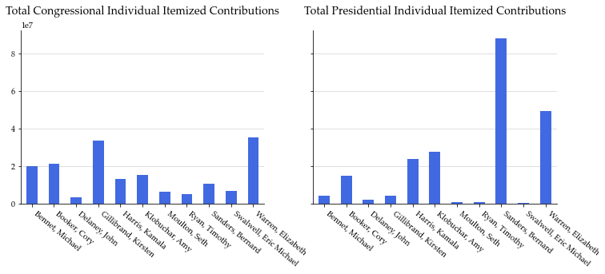

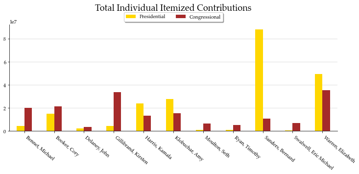

```python
def graph_fec_differences(fec_diff_df, column):
    """
    Takes a df formed with the compare_items function (with two columns, one for presidential and one for congressional)
    and returns a figure with two subplots, one with data from each column.
    """
    fig, ax = plt.subplots(1, 2, figsize=(12, 4), sharey=True)
    column_title = " ".join(column.title().split("_"))
    for i, cand_type in enumerate(["congressional", "presidential"]):
        a = ax[i]
        fec_diff_df.set_index("name")[column + " " + cand_type].plot(ax=a, kind="bar", xlabel="",
                                                                     zorder=2, color="royalblue",)
        a.set_title("Total " + cand_type.title() + " "+ column_title, pad=20, fontname="Palatino Linotype", fontweight=400, fontsize=14)
        a.set_xticklabels(a.get_xticklabels(), rotation=320, ha="left")
        a.grid(axis="y", zorder=0, alpha=0.5)
    remove_spines(ax)
#     fig.tight_layout()
    return fig

def one_graph_fec_differences(fec_diff_df, column):
    """
    Takes a df formed with the compare_items function (with two columns, one for presidential and one for congressional)
    and returns a figure with one plot, with a bar representing data from each column.
    """
    fig, a = plt.subplots(figsize=(12, 4), sharey=True)
    column_title = " ".join(column.title().split("_"))
#     a = ax[i]
    fec_diff_df.set_index("name").plot(ax=a, kind="bar", xlabel="",
                                                                 zorder=2, color=["gold", "brown"],)
    a.set_title("Total " + column_title, pad=30, fontname="Palatino Linotype", fontweight=400, fontsize=18)
    a.set_xticklabels(a.get_xticklabels(), rotation=320, ha="left")
    # make legend look nice
    handles, labels = a.get_legend_handles_labels()
    labels = ["Presidential", "Congressional"]
    a.legend(handles, labels, ncol=2, loc="center", bbox_to_anchor=(0.5, 1.07), fancybox=True, shadow=True)
    a.grid(axis="y", zorder=0, alpha=0.5)
    remove_spines(a)
#     fig.tight_layout()
    return fig
plt.rcParams["font.family"] = "Palatino Linotype"
fig = graph_fec_differences(ind_contributions_df, column)
fig_one = one_graph_fec_differences(ind_contributions_df, column)
# fig.savefig(image_path + "fec_ind_itemized.png", dpi=200, bbox_inches="tight")
# fig_one.savefig(image_path + "fec_one_ind_itemized.png", dpi=200, bbox_inches="tight")
```

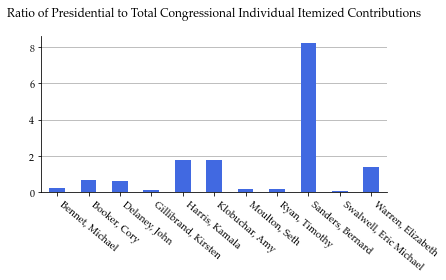

```python
def graph_fec_ratio(fec_diff_df, column):
    """
    Takes a df formed with the compare_items function (with two columns, one for presidential and one for congressional)
    and returns a figure with the ratio of presidential to congressional.
    """
    contributions_ratio = fec_diff_df[column + " presidential"].divide(fec_diff_df[column + " congressional"]).to_frame("presidential-to-congressional contributions").join(contributions_df[["name"]])
    column_title = " ".join(column.title().split("_"))
    fig, ax = plt.subplots()
    contributions_ratio.set_index("name").plot(ax=ax, kind="bar", legend=False, zorder=2, color="royalblue", xlabel="")
    ax.set_title("Ratio of Presidential to Total Congressional " + column_title, pad=20)
    ax.grid(axis="y", zorder=0)
    ax.set_xticklabels(ax.get_xticklabels(), rotation=320, ha="left")
    remove_spines(ax)
    fig.tight_layout()
    return fig
fig = graph_fec_ratio(ind_contributions_df, column)
# fig.savefig(image_path + "itemized_pres_cong_ratio.png", dpi=200, bbox_inches="tight")
```

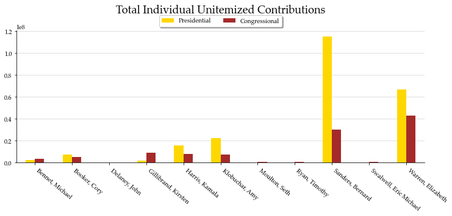

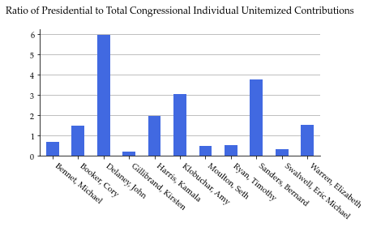

```python
def fec_compare_and_graph(pres_df, cong_df, column, agg_func=sum):
    """
    Given fec df corresponding with presidential fundraising data and congressional fundraising data creates two graphs;
    one shows presidential side-by-side with congressional (sum is default, could be mean, median, etc.)
    data for provided column.
    Returns both figures.
    """
    column_df = compare_items(pres_df, cong_df, [column], agg_func)
    fig_1 = one_graph_fec_differences(column_df, column)
    fig_2 = graph_fec_ratio(column_df, column)
    return fig_1, fig_2
column2 = "individual_unitemized_contributions"
fig_compare, fig_ratio = fec_compare_and_graph(cand_fec_money, cong_cand_fec_money, column2)
# fig_compare.savefig(image_path + "fec_one_ind_unitemized.png", dpi=200, bbox_inches="tight")
# fig_compare.savefig(image_path + "fec_ind_unitemized.png", dpi=200, bbox_inches="tight")
# fig_ratio.savefig(image_path + "unitemized_pres_cong_ratio.png", dpi=200, bbox_inches="tight")
```

*[Sanders example](https://www.fec.gov/data/candidate/P60007168/)

Note: this ratio needs to be paired with total fundraising graphs (which are above). Perhaps if one is already raising so much money in a congressional campaign, this ratio could be low, as their could be little room to elevate their fundraising relative to its normal amount.

*Note: DO NOT trust these numbers. This is preliminary analysis. Make sure I'm not double counting rows in df. GROUPBY election year, not cycle? or just say cycles 2018, 2020 for pres run?*

```python
# cong_cand_fec_money.info()
cong_cand_fec_money[["contributions", "net_contributions", "loans"]]
# cong_cand_fec_money[["candidate_contribution", "name"]].describe()
```

|  | contributions | net_contributions | loans |
| --- | --- | --- | --- |
| 0 | 1684901.87 | 1680012.87 | 108000.0 |
| 1 | 1656033.06 | 1651547.41 | 0.0 |
| 2 | 2211883.14 | 2183775.66 | 0.0 |
| 3 | 1410356.85 | 1386038.23 | 0.0 |
| 4 | 82761.58 | 74190.58 | 0.0 |
| ... | ... | ... | ... |
| 143 | 1047105.53 | 1037605.53 | 0.0 |
| 144 | 989459.96 | 978164.96 | 0.0 |
| 145 | 1068715.42 | 1057390.42 | 0.0 |
| 146 | 1358699.04 | 1342149.04 | 0.0 |
| 147 | 607910.49 | 601860.49 | 0.0 |

148 rows × 3 columns

### Further Questions/Paths for Analysis

- Yet another question: do congressmembers vote more with their party when they have the presidency? the house/senate?
- See if Senate nomination votes for each justice are a good predictor of partisan-ness?
- Who were the least effective whips? (i.e., which whips voted most against their parties?)
- Extend analysis to previous presidential races?
- Relation between presidential candidates' committee assignments/experience and most popular issues during presidential run?
- Apply statistical methods to quantify everything learned above